# SENDAs Agreement 1 Update 2010-2022 (Prediction, step 1)

Author

Andrés González Santa Cruz

Published

January 5, 2026

# Data Loading and Exploration

## Loading Packages and uniting databases

```r
# invisible("Only run from Ubuntu")
# if (!(Sys.getenv("RSTUDIO_SESSION_TYPE") == "server" || file.exists("/.dockerenv"))) {
#   if(Sys.info()["sysname"]!="Windows"){
#     Sys.setenv(RETICULATE_PYTHON = "/home/fondecytacc/.pyenv/versions/3.11.5/bin/python")
#   }
# }

#clean enviroment
rm(list = ls()); gc()

time_before_dedup2<-Sys.time()

#:#:#:#:#:#:#:#:#:#:#:#:#:#:#:#:#:#:#:#:#:#:#:#:#:#:#:#:#:#:#:#:#:#:#:#:
#:#:#:#:#:#:#:#:#:#:#:#:#:#:#:#:#:#:#:#:#:#:#:#:#:#:#:#:#:#:#:#:#:#:#:#:#:#:#:#:
#:#:#:#:#:#:#:#:#:#:#:#:#:#:#:#:#:#:#:#:#:#:#:#:#:#:#:#:#:#:#:#:#:#:#:#:

# Busca .mamba_root/envs/py311/python.exe desde getwd() hacia padres
find_python_rel <- function(start = getwd(),
                            rel = file.path(".mamba_root","envs","py311","python.exe")) {
  cur <- normalizePath(start, winslash = "/", mustWork = FALSE)
  repeat {
    cand <- normalizePath(file.path(cur, rel), winslash = "/", mustWork = FALSE)
    if (file.exists(cand)) return(cand)
    parent <- dirname(cur)
    if (identical(parent, cur)) return(NA_character_)  # llegó a la raíz
    cur <- parent
  }
}
# --- Bootstrap reticulate con ruta relativa a getwd() ---
if(Sys.info()["sysname"]!="Windows"){
  Sys.setenv(RETICULATE_PYTHON = "usr/bin/python3")
  reticulate::py_config()
} else {
  py <- find_python_rel()
  if (is.na(py)) {
    stop("No se encontró Python relativo a getwd() (buscando '.mamba_root/envs/py311/python.exe').\n",
         "Directorio actual: ", getwd())
  }
  # Forzar ese intérprete
  Sys.unsetenv(c("RETICULATE_CONDAENV","RETICULATE_PYTHON_FALLBACK"))
  Sys.setenv(RETICULATE_PYTHON = py)
  reticulate::use_python(py, required=T)
  reticulate::py_config()  # verificación
}
#_#_#_#_#_#_#_#_#_#_#_#_#_#_#_#_#_#_#_#_#_#_#_#_#_#_#_#_#_#_#_#_#_#_#_#_
#_#_#_#_#_#_#_#_#_#_#_#_#_#_#_#_#_#_#_#_#_#_#_#_#_#_#_#_#_#_#_#_#_#_#_#_

# --- Load 250927_c1_1025_df_prev1y.rds (simple, project-root aware, no functions) ---

# 1) Locate the file anywhere under the project root (current WD with a trailing "/cons" trimmed)
project_root <- sub("(/)?cons/?$", "", normalizePath(getwd(), winslash = "/", mustWork = FALSE))
fname        <- "251001_c1_1025_df_prev1y.rds"

hits <- list.files(project_root, pattern = paste0("^", fname, "$"),
                   recursive = TRUE, full.names = TRUE)

if (!length(hits)) stop("File not found: ", fname, "\nSearched under: ", project_root)
path <- hits[1]  # take first match

message("Loading: ", path)

# 2) Read into a dedicated environment (keeps .GlobalEnv clean)
env_prev1y <- new.env(parent = emptyenv())
obj        <- readRDS(path)
assign("SISTRAT23_c1_2010_2024_df_prev1y", obj, envir = env_prev1y)
rm(obj)

# 3) Quick sanity check
with(env_prev1y$SISTRAT23_c1_2010_2024_df_prev1y, { message("Rows: ", nrow(env_prev1y$SISTRAT23_c1_2010_2024_df_prev1y), " | Cols: ", ncol(env_prev1y$SISTRAT23_c1_2010_2024_df_prev1y));  print(str(env_prev1y$SISTRAT23_c1_2010_2024_df_prev1y))})
SISTRAT23_c1_2010_2024_df_prev1y<-
env_prev1y$SISTRAT23_c1_2010_2024_df_prev1y

rm(env_prev1y)
# (Optional) If you want it in the global env, uncomment:
# list2env(env_prev1y, envir = .GlobalEnv)
```

```
          used (Mb) gc trigger (Mb) max used (Mb)
Ncells  604456 32.3    1317361 70.4   961116 51.4
Vcells 1160482  8.9    8388608 64.0  1876213 14.4
python:         G:/My Drive/Alvacast/SISTRAT 2023/.mamba_root/envs/py311/python.exe
libpython:      G:/My Drive/Alvacast/SISTRAT 2023/.mamba_root/envs/py311/python311.dll
pythonhome:     G:/My Drive/Alvacast/SISTRAT 2023/.mamba_root/envs/py311
version:        3.11.5 | packaged by conda-forge | (main, Aug 27 2023, 03:23:48) [MSC v.1936 64 bit (AMD64)]
Architecture:   64bit
numpy:           [NOT FOUND]

NOTE: Python version was forced by RETICULATE_PYTHON
Classes 'tidytable', 'tbl', 'data.table' and 'data.frame':  162897 obs. of  125 variables:
 $ TABLE                        : chr  "2023" "2015" "2023" "2013" ...
 $ TABLE_rec_series             : chr  "||20232||" "||20151||" "||20231||" "||2013||" ...
 $ rn                           : int  240474 66234 225781 44305 69194 111875 235652 213374 14494 27258 ...
```

[output cut: 99 more lines]

```r
#https://github.com/rstudio/renv/issues/544
#renv falls back to copying rather than symlinking, which is evidently very slow in this configuration.
renv::settings$use.cache(FALSE)

#only use explicit dependencies (in DESCRIPTION)
renv::settings$snapshot.type("implicit")

#check if rstools is installed
if(Sys.info()["sysname"]=="Windows"){
try(installr::install.Rtools(check_r_update=F))
}
```

Installing package into ‘G:/My Drive/Alvacast/SISTRAT 2023/renv/library/windows/R-4.4/x86_64-w64-mingw32’ (as ‘lib’ is unspecified)

```r
check_quarto_version <- function(required = "1.7.29", comparator = c("ge","gt","le","lt","eq")) {
  comparator <- match.arg(comparator)
  current <- package_version(paste(unlist(quarto::quarto_version()), collapse = "."))
  req     <- package_version(required)

  ok <- switch(comparator,
               ge = current >= req,
               gt = current >  req,
               le = current <= req,
               lt = current <  req,
               eq = current == req)

  if (!ok) {
    stop(sprintf("Quarto version check failed: need %s %s (installed: %s).",
                 comparator, required, current), call. = FALSE)
  }
  invisible(TRUE)
}

check_quarto_version("1.7.29", "ge")

#change repository to CL
local({
  r <- getOption("repos")
  r["CRAN"] <- "https://cran.dcc.uchile.cl/"
  options(repos=r)
})

if(!require(pacman)){install.packages("pacman");require(pacman)}
```

Cargando paquete requerido: pacman

```r
if(!require(pak)){install.packages("pak");require(pak)}
```

Cargando paquete requerido: pak

```r
pacman::p_unlock(lib.loc = .libPaths()) #para no tener problemas reinstalando paquetes
```

No 00LOCK detected in: G:/My Drive/Alvacast/SISTRAT 2023/renv/library/windows/R-4.4/x86_64-w64-mingw32 No 00LOCK detected in: C:/Program Files/R/R-4.4.1/library

```r
if(Sys.info()["sysname"]=="Windows"){
if (getRversion() != "4.4.1") { stop("Requires R version 4.4.1; Actual: ", getRversion()) }
}

#check docker
check_docker_running <- function() {
  # Try running 'docker info' to check if Docker is running
  system("docker info", intern = TRUE, ignore.stderr = TRUE)
}
if(Sys.info()["sysname"]=="Windows"){
  install_docker <- function() {
    # Open the Docker Desktop download page in the browser for installation
    browseURL("https://www.docker.com/products/docker-desktop")
  }
  # Main logic
  if (inherits(try(check_docker_running(), silent = TRUE), "try-error")) {
    liftr::install_docker()
  } else {
    message("Docker is running.")
  }
}
```

Warning in system(“docker info”, intern = TRUE, ignore.stderr = TRUE): el comando ejecutado ‘docker info’ tiene el estatus 1

Docker is running.

```r
#_#_#_#_#_#_#_#_#_#_#_#_#_#_#_#_#_#_#_#_#_#_#_#_#_#_#_#_#_#_#_#_#_#_#_#_#_#_#_#_
#PACKAGES#######################################################################
#_#_#_#_#_#_#_#_#_#_#_#_#_#_#_#_#_#_#_#_#_#_#_#_#_#_#_#_#_#_#_#_#_#_#_#_#_#_#_#_

unlink("*_cache", recursive=T)

# ----------------------------------------------------------------------
# 2. Use a single pak::pkg_install() call for most CRAN packages
# ----------------------------------------------------------------------

paks <-
  c(#"git",
    # To connect to github
    "gh", #interface for  GitHub API from R
    #
    "gitcreds", # manages Git credentials (usernames, passwords, tokens)
    #
    "usethis", # simplifies common project setup tasks for R developers
    # Package to bring packages in development
    "devtools",
    # Package administration
    "renv",
    # To manipulate data
    "knitr", "pander", "DT",
    # Join
    "fuzzyjoin", "RecordLinkage",
    # For tables
    "tidyverse", "janitor",
    # For contingency tables
    "kableExtra",
    # For connections with python
    "reticulate",
    # To manipulate big data
    "polars", "sqldf",
    # To bring big databases
    "nanoparquet",
    # Interface for R and RStudio in R
    "installr", "rmarkdown", "quarto", "yaml", #"rstudioapi",
    # Time handling
    "clock",
    # Combine plots
    "ggpubr",
    # Parallelized iterative processing
    "furrr",
    # Work like a tibble with a data.table database
    "tidytable",
    # Split database into training and testing
    "caret",
    # Impute missing data
    "missRanger", "mice",
    # To modularize tasks
    "job",
    # For PhantomJS install checks
    "webshot"
  )

# dplyr
# janitor
# reshape2
# tidytable
# arrow
# boot
# broom
# car
# caret
# data.table
# DiagrammeR
# DiagrammeRsvg
# dplyr
# epiR
# epitools
# ggplot2
# glue
# htmlwidgets
# knitr
# lubridate
# naniar
# parallel
# polycor
# pROC
# psych
# readr
# rio
# rsvg
# scales
# stringr
# tableone
# rmarkdown
# biostat3
# codebook
# finalfit
# Hmisc
# kableExtra
# knitr
# devtools
# tidyr
# stringi
# stringr
# muhaz
# sqldf
# compareGroups
# survminer
# lubridate
# ggfortify
# car
# fuzzyjoin
# compareGroups
# caret
# job
# htmltools
# nanoparquet
# ggpubr
# polars
# installr
# clock
# pander
# reshape
# mice
# missRanger
# VIM
# withr
# biostat3
# broom
# glue
# finalfit
# purrr
# sf


# pak::pkg_install(paks)

pak::pak_sitrep()
# pak::sysreqs_check_installed(unique(unlist(paks)))
#pak::lockfile_create(unique(unlist(paks)),  "dependencies_duplicates24.lock", dependencies=T)
#pak::lockfile_install("dependencies_duplicates24.lock")
#https://rdrr.io/cran/pak/man/faq.html
#pak::cache_delete()

library(tidytable)
```

Adjuntando el paquete: ‘tidytable’

The following objects are masked from ‘package:stats’:

```
dt, filter, lag
```

The following object is masked from ‘package:base’:

```
%in%
```

```r
library(ggplot2)
library(readr)
library(glmulti)
```

Cargando paquete requerido: rJava

Cargando paquete requerido: leaps

```r
library(tableone)
library(survivalmodels)
#renv::install("patchwork@1.2.0")
library(survex)
library(SemiMarkov)
```

Cargando paquete requerido: numDeriv

Cargando paquete requerido: MASS

Adjuntando el paquete: ‘MASS’

The following object is masked from ‘package:tidytable’:

```
select
```

Cargando paquete requerido: Rsolnp

```r
library(flexsurv)
```

Cargando paquete requerido: survival

```r
library(rms)
```

Cargando paquete requerido: Hmisc

Adjuntando el paquete: ‘Hmisc’

The following object is masked from ‘package:tidytable’:

```
summarize
```

The following objects are masked from ‘package:base’:

```
format.pval, units
```

```r
library(survidm)
library(caret)
```

Cargando paquete requerido: lattice

Adjuntando el paquete: ‘caret’

The following object is masked from ‘package:survival’:

```
cluster
```

```r
# library(shapr)#https://norskregnesentral.github.io/shapr/
# library(survidm)#https://sci-hub.ee/10.1002/bimj.201700200
# library(SemiMarkov)#https://www.degruyterbrill.com/document/doi/10.1515/ijb-2020-0083/html?lang=en
# #https://www.jclinepi.com/article/S0895-4356(24)00142-2/fulltext

# ----------------------------------------------------------------------
# 3. Activate polars code completion (safe to try even if it fails)
# ----------------------------------------------------------------------
#try(polars_code_completion_activate())

# ----------------------------------------------------------------------
# 4. BPMN from GitHub (not on CRAN, so install via devtools if missing)
# ----------------------------------------------------------------------
if (!requireNamespace("bpmn", quietly = TRUE)) {
  devtools::install_github("bergant/bpmn")
}

# ----------------------------------------------------------------------
# 5. PhantomJS Check (use webshot if PhantomJS is missing)
# ----------------------------------------------------------------------
# if (!webshot::is_phantomjs_installed()) {
#   webshot::install_phantomjs()
# }

#_#_#_#_#_#_#_#_#_#_#_#_#_#_#_#_#_#_#_#_#_#_#_#_#_#_#_#_#_#_#_#_#_#_#_#_#_#_#_#_
#FUNCTIONS######################################################################
#_#_#_#_#_#_#_#_#_#_#_#_#_#_#_#_#_#_#_#_#_#_#_#_#_#_#_#_#_#_#_#_#_#_#_#_#_#_#_#_

#:#:#:#:#:#:#:#:#:#:#:#:#:#:#:#:#:#:#:#:#:#:#:#:#:#:#:#:#:#:#:#:#:#:#:#:#:#:#:#:#:#:#:#:#:#:#:#:#:#:#:#
# NO MORE DEBUGS
options(error = NULL)        # si antes tenías options(error = recover) o browser)
options(browserNLdisabled = FALSE)


#:#:#:#:#:#:#:#:#:#:#:#:#:#:#:#:#:#:#:#:#:#:#:#:#:#:#:#:#:#:#:#:#:#:#:#:#:#:#:#:#:#:#:#:#:#:#:#:#:#:#:#
#NAs are replaced with "" in knitr kable
options(knitr.kable.NA = '')

pander::panderOptions('big.mark', ',')
pander::panderOptions('decimal.mark', '.')

#:#:#:#:#:#:#:#:#:#:#:#:#:#:#:#:#:#:#:#:#:#:#:#:#:#:#:#:#:#:#:#:#:#:#:#:#:#:#:#:#:#:#:#:#:#:#:#:#:#:#:#

#to format rows in bold
format_cells <- function(df, rows ,cols, value = c("italics", "bold", "strikethrough")){

  # select the correct markup
  # one * for italics, two ** for bold
  map <- setNames(c("*", "**", "~~"), c("italics", "bold", "strikethrough"))
  markup <- map[value]

  for (r in rows){
    for(c in cols){

      # Make sure values are not factors
      df[[c]] <- as.character( df[[c]])

      # Update formatting
      df[r, c] <- ifelse(nchar(df[r, c])==0,"",paste0(markup, gsub(" ", "", df[r, c]), markup))
    }
  }

  return(df)
}
#To produce line breaks in messages and warnings
knitr::knit_hooks$set(
   error = function(x, options) {
     paste('\n\n<div class="alert alert-danger" style="font-size: small !important;">',
           gsub('##', '\n', gsub('^##\ Error', '**Error**', x)),
           '</div>', sep = '\n')
   },
   warning = function(x, options) {
     paste('\n\n<div class="alert alert-warning" style="font-size: small !important;">',
           gsub('##', '\n', gsub('^##\ Warning:', '**Warning**', x)),
           '</div>', sep = '\n')
   },
   message = function(x, options) {
     paste('<div class="message" style="font-size: small !important;">',
           gsub('##', '\n', x),
           '</div>', sep = '\n')
   }
)

#:#:#:#:#:#:#:#:#:#:#:#:#:#:#:#:#:#:#:#:#:#:#:#:#:#:#:#:#:#:#:#:#:#:#:#:#:#:#:#:#:#:#:#:#:#:#:#:#:#:#:#

sum_dates <- function(x){
  cbind.data.frame(
    min= as.Date(min(unclass(as.Date(x)), na.rm=T), origin = "1970-01-01"),
    p001= as.Date(quantile(unclass(as.Date(x)), .001, na.rm=T), origin = "1970-01-01"),
    p005= as.Date(quantile(unclass(as.Date(x)), .005, na.rm=T), origin = "1970-01-01"),
    p025= as.Date(quantile(unclass(as.Date(x)), .025, na.rm=T), origin = "1970-01-01"),
    p25= as.Date(quantile(unclass(as.Date(x)), .25, na.rm=T), origin = "1970-01-01"),
    p50= as.Date(quantile(unclass(as.Date(x)), .5, na.rm=T), origin = "1970-01-01"),
    p75= as.Date(quantile(unclass(as.Date(x)), .75, na.rm=T), origin = "1970-01-01"),
    p975= as.Date(quantile(unclass(as.Date(x)), .975, na.rm=T), origin = "1970-01-01"),
    p995= as.Date(quantile(unclass(as.Date(x)), .995, na.rm=T), origin = "1970-01-01"),
    p999= as.Date(quantile(unclass(as.Date(x)), .999, na.rm=T), origin = "1970-01-01"),
    max= as.Date(max(unclass(as.Date(x)), na.rm=T), origin = "1970-01-01")
  )
}

#:#:#:#:#:#:#:#:#:#:#:#:#:#:#:#:#:#:#:#:#:#:#:#:#:#:#:#:#:#:#:#:#:#:#:#:#:#:#:#:#:#:#:#:#:#:#:#:#:#:#:#:#:#:#:

# Define the function adapted for Polars
sum_dates_polars <- function(df, date_col) {
  # Create the list of quantiles
  quantiles <- c(0.001, 0.005, 0.025, 0.25, 0.5, 0.75, 0.975, 0.995, 0.999)
  # Create expressions to calculate min and max
  expr_list <- list(
    pl$col(date_col)$min()$alias("min"),
    pl$col(date_col)$max()$alias("max")
  )
  # Add expressions for quantiles
  for (q in quantiles) {
    expr_list <- append(expr_list, pl$col(date_col)$quantile(q)$alias(paste0("p", sub("\\.", "", as.character(q)))))
  }
  # Apply the expressions and return a DataFrame with the results
  df$select(expr_list)
}

# Custom function for sampling with a seed
sample_n_with_seed <- function(data, size, seed) {
  set.seed(seed)
  dplyr::sample_n(data, size)
}

# Function to get the most frequent value
most_frequent <- function(x) {
  uniq_vals <- unique(x)
  freq_vals <- sapply(uniq_vals, function(val) sum(x == val))
  most_freq <- uniq_vals[which(freq_vals == max(freq_vals))]

  if (length(most_freq) == 1) {
    return(most_freq)
  } else {
    return(NA)
  }
}
#_#_#_#_#_#_#_#_#_#_#_#_#_#_#_#_#_#_#_#_#_#_#_#_#_#_#_#_#_#_#_#_#_#_#_#_#_#_#_#_
#CONFIG #######################################################################
#_#_#_#_#_#_#_#_#_#_#_#_#_#_#_#_#_#_#_#_#_#_#_#_#_#_#_#_#_#_#_#_#_#_#_#_#_#_#_#_

options(scipen=2) #display numbers rather scientific number

#_#_#_#_#_#_#_#_#_#_#_#_#_#_#_#_#_#_#_#_#_#_#_#_#_#_#_#_#_#_#_#_#_#_#_#_#_#_#_#_

# Define the function first
#joins these values with semicolons and optionally truncates the result if it exceeds a specified width.
toString2 <- function(x, width = NULL, ...) {
    string <- paste(x, collapse = "; ")
    if (missing(width) || is.null(width) || width == 0)
        return(string)
    if (width < 0)
        stop("'width' must be positive")
    if (nchar(string, type = "w") > width) {
        width <- max(6, width)
        string <- paste0(substr(string, 1, width - 3), "...")
    }
    string
}
normalize_txt <- function(x) {
  x|>
    stringi::stri_trans_general("Latin-ASCII")|>
    tolower()|>
    trimws()
}

pair_str <- function(main, sub) {
  main <- as.character(main)
  sub  <- as.character(sub)
  both_na <- is.na(main) & is.na(sub)

  out <- paste0(
    tidytable::coalesce(main, "NA"),
    "::",
    tidytable::coalesce(sub,  "NA")
  )

  out[both_na] <- NA_character_
  out
}

# ── Helpers ────────────────────────────────────────────────────────────
mode_pick_int <- function(x){
  x <- x[!is.na(x)]
  if(length(x)==0) return(NA_integer_)
  tx <- sort(table(x), decreasing = TRUE)
  as.integer(names(tx)[1L])
}

subkey_to_label <- function(x){
  y <- gsub("_"," ", tolower(x))
  y <- gsub("amphetamine type stimulants","amphetamine-type stimulants", y)
  y <- gsub("tranquilizers hypnotics","tranquilizers/hypnotics", y)
  y
}

#:#:#:#:#:#:#:#:#:#:#:#:#:#:#:#:#:#:#:#:#:#:#:#:#:#:#:#:#:#:#:#:#:#:#:#:
#:#:#:#:#:#:#:#:#:#:#:#:#:#:#:#:#:#:#:#:#:#:#:#:#:#:#:#:#:#:#:#:#:#:#:#:
# ── Encryption ────────────────────────────────────────────────────────

# Pack: [24-byte nonce][ciphertext] -> hex
encrypt_chr <- function(x, key) {
    vapply(x, function(v) {
        if (is.na(v)) return(NA_character_)
        ct <- sodium::data_encrypt(charToRaw(as.character(v)), key)
        nonce <- attr(ct, "nonce")                 # 24 bytes
        sodium::bin2hex(c(nonce, ct))              # pack nonce + ct
    }, FUN.VALUE = character(1))
}

# Unpack: hex -> [nonce|ciphertext], restore attr(nonce), then decrypt
decrypt_chr <- function(x, key) {
    vapply(x, function(v) {
        if (is.na(v)) return(NA_character_)
        buf <- sodium::hex2bin(v)
        if (length(buf) < 25L) stop("Ciphertext too short or corrupted.")
        nonce <- buf[1:24]
        ct    <- buf[-(1:24)]
        attr(ct, "nonce") <- nonce
        rawToChar(sodium::data_decrypt(ct, key))
    }, FUN.VALUE = character(1))
}

# Function to encrypt a character vector
encrypt_column <- function(x, key) {
  sapply(x, function(item) {
    if (is.na(item) || item == "") {
      return(NA_character_)
    }
    encrypted_raw <- sodium::data_encrypt(charToRaw(item), key)
    base64enc::base64encode(encrypted_raw)  # Convert to base64 for storage
  }, USE.NAMES = FALSE)
}

decrypt_column <- function(x, key) {
  sapply(x, function(item) {
    if (is.na(item)) return(NA_character_)
    encrypted_raw <- base64enc::base64decode(item)
    rawToChar(sodium::data_decrypt(encrypted_raw, key))
  }, USE.NAMES = FALSE)
}


is_stata_ok <- function(x) {
  nchar(x) <= 32 & grepl("^[A-Za-z][A-Za-z0-9_]*$", x)
}


#:#:#:#:#:#:#:#:#:#:#:#:#:#:#:#:#:#:#:#:#:#:#:#:#:#:#:#:#:#:#:#:#:#:#:#:
#:#:#:#:#:#:#:#:#:#:#:#:#:#:#:#:#:#:#:#:#:#:#:#:#:#:#:#:#:#:#:#:#:#:#:#:
# ── Tidy RMS ────────────────────────────────────────────────────────

tidy_cph <- function(model) {
  if (!inherits(model, "cph")) stop("Model must be an rms::cph object")

  # run summary
  s <- summary(model)
  df_s <- as.data.frame(unclass(s))
  df_s$rown <- rownames(s)

  # find rows that are "Hazard Ratio"
  hr_rows <- trimws(df_s$rown) == "Hazard Ratio"

  # build tidy tibble
  tibble::tibble(
    term     = trimws(rownames(s)[which(hr_rows) - 1L]), # previous row = variable name
    estimate = df_s$Effect[hr_rows],                     # Hazard Ratio
    conf.low = df_s$`Lower 0.95`[hr_rows],
    conf.high= df_s$`Upper 0.95`[hr_rows],
    p.value  = df_s$P[hr_rows]
  )
}

#:#:#:#:#:#:#:#:#:#:#:#:#:#:#:#:#:#:#:#:#:#:#:#:#:#:#:#:#:#:
#:#:#:#:#:#:#:#:#:#:#:#:#:#:#:#:#:#:#:#:#:#:#:#:#:#:#:#:#:#:
#:#:#:#:#:#:#:#:#:#:#:#:#:#:#:#:#:#:#:#:#:#:#:#:#:#:#:#:#:#:
# --- Step 1: Define File Paths ---

# SET THIS to the correct path of your secret text file
secret_file_path <- "C:/Users/andre/Documents/secret.txt"
# This locates the user-level .Renviron file automatically
renviron_path <- file.path(Sys.getenv("HOME"), ".Renviron")
# --- Step 2: Read the Secret Key from the .txt file ---
# Read the first line of the file and trim any whitespace
api_key <- trimws(readLines(secret_file_path, n = 1, warn = FALSE))
# --- Step 3: Check if the key is already in .Renviron ---
# Read all existing lines from .Renviron (if it exists)
if (file.exists(renviron_path)) {
  existing_lines <- readLines(renviron_path, warn = FALSE)
} else {
  existing_lines <- c()
}
# Check if a line for OPENAI_API_KEY already exists
key_exists <- any(grepl("^OPENAI_API_KEY=", existing_lines))
# --- Step 4: Write to .Renviron if the key isn't already there ---
if (!key_exists) {
  # Format the line to be added
  line_to_add <- sprintf('OPENAI_API_KEY="%s"', api_key)
  # Append the line to the .Renviron file, adding a newline before it if the file isn't empty
  cat(line_to_add, "\n", file = renviron_path, append = TRUE)
  message("✅ Success! OPENAI_API_KEY has been added to your .Renviron file.")
  message("Please restart your R session for the change to take effect.")
} else {
  message("ℹ️ The OPENAI_API_KEY already exists in your .Renviron file. No changes were made.")
}
```

ℹ️ The OPENAI_API_KEY already exists in your .Renviron file. No changes were made.

```r
options(.gander_chat = ellmer::chat_openai(model = "o1-mini"))
```

[output not shown]

**Note**

**Data Pre-processing and Feature Engineering**

Outliers in continuous variables will be managed using Tukey’s method, where values beyond 1.5 times the interquartile range (IQR) from the first or third quartile are flagged for review.

The analysis will incorporate 14 predictor variables, including three continuous variables. To model non-linear relationships, we will generate transformed variables, including logarithmic (log(x)), quadratic (x<sup>2</sup>), and cubic (x^3) terms. Additionally, some continuous variables may be discretized into categorical features.

If required, continuous predictors will be zero-centered and scaled by a factor to improve the model’s computational performance and numerical stability.

**Aims**

- To identify key prognostic and predictive factors associated with the risk of, and time to, the first readmission to treatment among patients aged 18-64 undergoing initial treatment for Substance Use Disorder (SUD) in Chile between 2010 and 2020.
- To identify key prognostic and predictive factors associated with the risk of, and time to, all-cause mortality among the same cohort of patients undergoing initial treatment for SUD in Chile.
- To predict the risk and timing of first treatment readmission and all-cause mortality simultaneously, treating these outcomes within a semi-competing risks framework. This will allow for the estimation of cumulative incidence for each event in the presence of the other for patients aged 18-64 who initiated SUD treatment in Chile between 2010 and 2020.

This study has three primary objectives. First, we aim to identify key prognostic and predictive factors associated with the risk and timing of two critical outcomes: (i) first readmission to treatment and (ii) all-cause mortality. Second, using a semi-competing risks framework, we will develop a model to simultaneously predict these two outcomes, accounting for the fact that death precludes the possibility of readmission. Finally, this model will be used to estimate the probability of various patient trajectories over time following initial treatment. The study population includes all patients aged 18-64 who began treatment for Substance Use Disorder (SUD) in Chile between 2010 and 2020.

## 1. Structure of treatments and rules to collapse continuous entries

**The variables involved in the analysis are the following:**.

- **Time to first readmission from admission** `readmit_time_from_adm_m` **/ from discharge** `readmit_time_from_disch_m` **in months**, and **event** (`readmit_event`)
- **Time to mortality** `death_time_from_adm_m` **/ from discharge** `death_time_from_disch_m` **in months**, and **event** (`death_event`) Predisposing factors:
- **Admission age** `adm_age_rec3` [log1p(x)=`adm_age_log`, centered= `adm_age_c`,^2=`adm_age_pow2`, ^3=`adm_age_pow3`, three groups= `adm_age_rec3_cat`]
- **Sex** (often used for biological categorization) `sex_rec`
- **Housing situation** `tenure_status_household_rec`
- **Employment status** `occupation_condition_corr24`
- **Marital status** `marital_status_rec`
- **Poverty index of the commune of residence** `porc_pobr` [log1p(x)=`porc_pobr_log`, centered= `porc_pobr_c`, six quantile groups= `porc_pobr_c_cat6`]
- **Urbanization level of the commune of residence** `urbanicity_cat`
- **Educational attainment** `ed_attainment_corr`
- **Living arrangement/Cohabitation status** `cohabitation`

Need factors: * **Psychiatric comorbidity** `dg_psiq_cie_10_instudy` + `dg_psiq_cie_10_dg` * **Severity of Substance Use Disorder (SUD)** `sub_dep_icd10_status` * **Primary substance of use** `primary_sub_mod` * **Frequency of primary substance use at admission** `prim_sub_freq` (recoded: `prim_sub_freq_rec`) * **Polysubstance use** `polysubstance_strict`

Enabling factors: * **Length of stay in treatment (months)** `dit_rec6` [log1p(x)=`treat_log`, ^2=`treat_days_pow2`, ^3=`treat_days_pow3`, <90days=`treat_lt_90`] * **Treatment outcome** `tr_outcome` * **Admission motive** `adm_motive`

**Suitable for a research context:**.

- **Court-referred to drug treatment** `usuario_tribunal_trat_droga` (very unbalanced, ~1% yes)
- **Type of housing** `tipo_de_vivienda_rec`

**Stratification variables:**.

- **Treatment modality** `plan_type_corr`

### 1.1. Cohort Construction for Time-to-Event Analysis

- **What can I do with adm truncated (0.2%), and currently in (0.1%)??**

We created a formatted database in wide format for multistate analysis (`SISTRAT23_c1_2010_2024_df_prev1z`).

```r
# --- Safe helpers (no warnings) ---
safe_min_where_int  <- function(x, flag) {
  idx <- which(flag %in% TRUE & !is.na(x))
  if (length(idx) == 0L) NA_integer_ else as.integer(min(x[idx]))
}
safe_min_where_date <- function(x, flag) {
  idx <- which(flag %in% TRUE & !is.na(x))
  if (length(idx) == 0L) as.Date(NA) else min(x[idx])
}
safe_min_date <- function(x) {
  x <- x[!is.na(x)]
  if (length(x) == 0L) as.Date(NA) else min(x)
}

# Windows of interest
.start_date  <- as.Date("2010-01-01")
.end_date    <- as.Date("2020-12-31")
.censor_date <- as.Date("2020-12-31")

# 0) Start & canonical order + treatment index
df0 <- SISTRAT23_c1_2010_2024_df_prev1y|>
  tidytable::ungroup()|>
  tidytable::arrange(hash_key, adm_date_rec2, disch_date_rec6)|>
  tidytable::mutate(treatment = tidytable::row_number(), .by = hash_key)

n0_cases <- nrow(df0)
n0_runs  <- nrow(tidytable::distinct(df0, hash_key))

message("0. INITIAL database, cases: ", formatC(nrow(df0), big.mark=","), sep = "")
```

0. INITIAL database, cases: 162,897

```r
message("0. INITIAL database, RUNs: " , formatC(nrow(tidytable::distinct(df0, hash_key)), big.mark=","), sep = "")
```

0. INITIAL database, RUNs: 121,299

```r
# 1) Qualifying flag (age 18–65 & admission in 2010–2020 inclusive)
df1 <- df0|>
  tidytable::mutate(
    meets_crit = !is.na(adm_age_rec3)  & adm_age_rec3 >= 18 & adm_age_rec3 <= 64 &
                 !is.na(adm_date_rec2) & adm_date_rec2 >= .start_date & adm_date_rec2 <= .end_date
  )

# First qualifying treatment per patient + counter of discarded priors (no warnings)
first_keep_tbl <- df1|>
  tidytable::summarise(
    first_keep_treat = safe_min_where_int(treatment, meets_crit),
    .by = hash_key
  )|>
  tidytable::mutate(
    n_discarded_before = ifelse(is.na(first_keep_treat), NA_integer_,
                                as.integer(first_keep_treat - 1L))
  )

n_patients_meet <- first_keep_tbl|> tidytable::filter(!is.na(first_keep_treat))|> nrow()
message("1. Patients with ≥1 qualifying admission (age 18–64 & 2010–2020): ",
        formatC(n_patients_meet, big.mark=","), sep = "")
```

1. Patients with ≥1 qualifying admission (age 18–64 & 2010–2020): 88,632

```r
# 2) Keep ONLY qualifying episodes; rank; drop 3rd+
df_q <- df1|>
  tidytable::filter(meets_crit)|>
  tidytable::arrange(hash_key, adm_date_rec2, disch_date_rec6)|>
  tidytable::mutate(q_rank = tidytable::row_number(), .by = hash_key)|>
  tidytable::filter(q_rank <= 2L)

n1b_cases <- nrow(df_q)
n1b_patients <- nrow(tidytable::distinct(df_q, hash_key))
message("1b. AFTER filtering to qualifying episodes, cases: ",
        formatC(nrow(df_q), big.mark=","), sep = "")
```

1b. AFTER filtering to qualifying episodes, cases: 107,702

```r
message("1b. AFTER filtering to qualifying episodes, RUNs: ",
        formatC(nrow(tidytable::distinct(df_q, hash_key)), big.mark=","), sep = "")
```

1b. AFTER filtering to qualifying episodes, RUNs: 88,632

```r
message("2. AFTER dropping ≥3rd qualifying treatments per patient, cases: ",
        formatC(nrow(df_q), big.mark=","), sep = "")
```

2. AFTER dropping ≥3rd qualifying treatments per patient, cases: 107,702

```r
message("2. AFTER dropping ≥3rd qualifying treatments per patient, RUNs: ",
        formatC(nrow(tidytable::distinct(df_q, hash_key)), big.mark=","), sep = "")
```

2. AFTER dropping ≥3rd qualifying treatments per patient, RUNs: 88,632

```r
# 3) Anchors per patient (warning-free)
anchors <- df_q|>
  tidytable::summarise(
    first_adm   = safe_min_where_date(adm_date_rec2,   q_rank == 1L),
    first_disch = safe_min_where_date(disch_date_rec6, q_rank == 1L),
    second_adm  = safe_min_where_date(adm_date_rec2,   q_rank == 2L),  # NA if no second qualifying
    .by = hash_key
  )

# Death date per patient (from full data, not only qualifying rows)
death_tbl <- df0|>
  tidytable::summarise(death_date = safe_min_date(def_date), .by = hash_key)

# 4) Build per-person time-to-event (no min() calls here)
perperson <- df_q|>
  tidytable::distinct(hash_key)|>
  tidytable::left_join(anchors,       by = "hash_key")|>
  tidytable::left_join(death_tbl,     by = "hash_key")|>
  tidytable::left_join(first_keep_tbl, by = "hash_key")|>
  tidytable::mutate(
    # Event indicators with censoring at 2020-12-31
    readmit_event = as.integer(!is.na(second_adm) & second_adm <= .censor_date),
    death_event   = as.integer(!is.na(death_date)  & death_date  <= .censor_date),

    # End times for intervals (choose event time or censor date)
    readmit_end_from_adm   = ifelse(readmit_event == 1L, second_adm, .censor_date),
    readmit_end_from_disch = ifelse(readmit_event == 1L, second_adm, .censor_date),
    death_end_from_adm     = ifelse(death_event   == 1L, death_date, .censor_date),
    death_end_from_disch   = ifelse(death_event   == 1L, death_date, .censor_date),

    # Durations (months) from first qualifying admission/discharge
    readmit_time_from_adm_m =
      ifelse(!is.na(first_adm),
        as.numeric(lubridate::time_length(lubridate::interval(first_adm,   readmit_end_from_adm),   "months")),
        NA_real_),
    readmit_time_from_disch_m =
      ifelse(!is.na(first_disch),
        as.numeric(lubridate::time_length(lubridate::interval(first_disch, readmit_end_from_disch), "months")),
        NA_real_),
    death_time_from_adm_m =
      ifelse(!is.na(first_adm),
        as.numeric(lubridate::time_length(lubridate::interval(first_adm,   death_end_from_adm),     "months")),
        NA_real_),
    death_time_from_disch_m =
      ifelse(!is.na(first_disch),
        as.numeric(lubridate::time_length(lubridate::interval(first_disch, death_end_from_disch),   "months")),
        NA_real_)
  )|>
  # Clamp negatives (dirty dates safeguard)
  tidytable::mutate(
    readmit_time_from_adm_m   = ifelse(!is.na(readmit_time_from_adm_m),   pmax(readmit_time_from_adm_m,   0), NA_real_),
    readmit_time_from_disch_m = ifelse(!is.na(readmit_time_from_disch_m), pmax(readmit_time_from_disch_m, 0), NA_real_),
    death_time_from_adm_m     = ifelse(!is.na(death_time_from_adm_m),     pmax(death_time_from_adm_m,     0), NA_real_),
    death_time_from_disch_m   = ifelse(!is.na(death_time_from_disch_m),   pmax(death_time_from_disch_m,   0), NA_real_)
  )|>
  tidytable::mutate(discarded_before_flag = as.integer(n_discarded_before > 0L))

# 5) FINAL: keep only the first qualifying treatment row per patient, carry times/counters
SISTRAT23_c1_2010_2024_df_prev1z <-
  df_q|>
  tidytable::filter(q_rank == 1L)|>
  tidytable::left_join(perperson, by = "hash_key")|>
  tidytable::select(-meets_crit, -q_rank)|>
  (\(df){

    n_cases   <- nrow(df)
    n_runs    <- tidytable::distinct(df, hash_key) |> nrow()
    red_cases <- nrow(df0) - n_cases
    red_runs  <- (tidytable::distinct(df0, hash_key) |> nrow()) - n_runs
    readmit   <- sum(df$readmit_event)

    # store (step 3)
    n_cases   ->> m3_cases
    n_runs    ->> m3_runs
    red_cases ->> m3_cases_red
    red_runs  ->> m3_runs_red
    list(cases=n_cases, runs=n_runs, readmit=readmit, cases_red=red_cases, runs_red=red_runs) ->> m3

    message("3. FINAL: first qualifying treatment per patient (with time-to-event), cases: ",
            formatC(n_cases, big.mark=","), sep = "")
    message("3. FINAL: RUNs: ", formatC(n_runs, big.mark=","), sep = "")
    message("   CASES reduction vs initial(prev1y): ", formatC(red_cases, big.mark=","), sep = "")
    message("   RUNs  reduction vs initial(prev1y): ", formatC(red_runs,  big.mark=","), sep = "")

    if (n_cases > nrow(df0)) stop("Error: Added treatment episodes in the process")
    df
  })() |>
  tidytable::filter(!tr_compliance_rec7 == "currently in") |>
  (\(df){

    n_cases   <- nrow(df)
    n_runs    <- tidytable::distinct(df, hash_key) |> nrow()
    red_cases <- nrow(df0) - n_cases
    red_runs  <- (tidytable::distinct(df0, hash_key) |> nrow()) - n_runs

    # store (step 4)
    n_cases   ->> m4_cases
    n_runs    ->> m4_runs
    red_cases ->> m4_cases_red
    red_runs  ->> m4_runs_red
    list(cases=n_cases, runs=n_runs, cases_red=red_cases, runs_red=red_runs) ->> m4

    message("4. FINAL: leaving out patients currently in tr., cases: ",
            formatC(n_cases, big.mark=","), sep = "")
    message("4. FINAL: RUNs: ", formatC(n_runs, big.mark=","), sep = "")
    message("   CASES reduction vs initial(prev1y): ", formatC(red_cases, big.mark=","), sep = "")
    message("   RUNs  reduction vs initial(prev1y): ", formatC(red_runs,  big.mark=","), sep = "")

    df
  })()
```

3. FINAL: first qualifying treatment per patient (with time-to-event), cases: 88,632
3. FINAL: RUNs: 88,632

CASES reduction vs initial(prev1y): 74,265

RUNs reduction vs initial(prev1y): 32,667

4. FINAL: leaving out patients currently in tr., cases: 88,504
4. FINAL: RUNs: 88,504

CASES reduction vs initial(prev1y): 74,393

RUNs reduction vs initial(prev1y): 32,795

```r
#SISTRAT23_c1_2010_2024_df_prev1z |> filter(is.na(dit_m)) |> janitor::tabyl(tr_compliance_rec7, show_na = T)
SISTRAT23_c1_2010_2024_df_prev1z$porc_pobr_c_cat6<- cut2(SISTRAT23_c1_2010_2024_df_prev1z$porc_pobr_c,g=6)

cat("Remove intermediate databases\n")
rm(df0); rm(df1); rm(df_q); rm(anchors); rm(death_tbl); rm(first_keep_tbl)
#_#_#_#_#_#_#_#_#_#_#_#_#_#_#_#_#_#_#_#_#_#_#_#_#_#_#_#_#_#_#_#_#_#_#_#_#_#_#_#_#_#_#_#_#_#_#_#_#_#_#_#_
#_#_#_#_#_#_#_#_#_#_#_#_#_#_#_#_#_#_#_#_#_#_#_#_#_#_#_#_#_#_#_#_#_#_#_#_#_#_#_#_#_#_#_#_#_#_#_#_#_#_#_#_
#_#_#_#_#_#_#_#_#_#_#_#_#_#_#_#_#_#_#_#_#_#_#_#_#_#_#_#_#_#_#_#_#_#_#_#_#_#_#_#_#_#_#_#_#_#_#_#_#_#_#_#_


# --- choose your time origin for the multistate ---
.use_discharge_origin <- FALSE   # TRUE = origin at first_disch; FALSE = origin at first_adm

# Add origin_date
if (.use_discharge_origin) {
  perperson <- tidytable::mutate(SISTRAT23_c1_2010_2024_df_prev1z, origin_date = first_disch)
} else {
  perperson <- tidytable::mutate(SISTRAT23_c1_2010_2024_df_prev1z, origin_date = first_adm)
}

# 1) Drop patients who die before the origin (they never enter the process)
n_drop_predeath <- tidytable::filter(perperson, !is.na(death_date) & !is.na(origin_date) & death_date < origin_date) |>
  nrow()
message("A. Excluding patients who died before origin: ",
        formatC(n_drop_predeath, big.mark=","), sep = "")
```

A. Excluding patients who died before origin: 0

```r
stopifnot(
nrow(tidytable::filter(perperson, is.na(death_date) | is.na(origin_date) | death_date >= origin_date))== nrow(SISTRAT23_c1_2010_2024_df_prev1z)
)
# 2) Keep only those whose origin is observed and within study window (optional but recommended)
n_before <- nrow(SISTRAT23_c1_2010_2024_df_prev1z)
perperson2 <- tidytable::filter(perperson, !is.na(origin_date) & origin_date <= .censor_date)
message("B. Excluding missing/after-censor origins: ",
        formatC(n_before - nrow(perperson2), big.mark=","), sep = "")
```

B. Excluding missing/after-censor origins: 0

```r
# 3) Ensure monotone times: second_adm must be after origin (else reclassify as 'no readmission')
# perperson <- tidytable::mutate(perperson,
#     invalid_readmit = !is.na(second_adm) & second_adm <= origin_date,
#     second_adm      = ifelse(invalid_readmit, as.Date(NA), second_adm),
#     readmit_event   = ifelse(invalid_readmit, 0L, readmit_event)
#   )

rm(perperson); rm(perperson2)
```

```
Remove intermediate databases
```

#### 1.1.* Flowchart

```r
#For SISTRAT23_c1_2010_2024_df_prev1t
try(load(paste0(dirname(path),"/SISTRAT_database_sep25_prevt.RData")))

#n_patients_meet;n1b_cases; n1b_patients; m4; m3

df23_ndp_20250824_SISTRAT23_c1_1024<-
 readRDS(
   paste0(dirname(path),"/psu/23_ndp_20250824_SISTRAT23_c1_1024_df2.rds")
 )

# Labels
lab_orig <- paste0(
  "Original C1 Dataset \n(n = ",
  formatC(nrow(df23_ndp_20250824_SISTRAT23_c1_1024), format = "f", big.mark = ",", digits = 0),
  "; Patients = ",
  formatC(dplyr::n_distinct(df23_ndp_20250824_SISTRAT23_c1_1024$hash_key), format = "f", big.mark = ",", digits = 0),
  ")"
)

lab_orig_clean <- paste(
  "Pre-processing & Quality Checks",
  "&#8226; Remove exact duplicate records",
  "&#8226; Resolve overlapping episodes (keep longest / merge)",
  "&#8226; Fix inconsistent admission/discharge dates",
  "&#8226; Correct implausible birth dates/ages",
  "&#8226; Remove negative/implausible days in treatment",
"",
  sep = "\\l"
)
lab_post_orig  <- paste0('C1 Dataset \n(n = ', formatC(nrow(SISTRAT23_c1_2010_2024_df_prev1t), format='f', big.mark=',', digits=0), '; Patients = ',formatC(dplyr::distinct(SISTRAT23_c1_2010_2024_df_prev1t, hash_key)|> nrow(), format='f', big.mark=',', digits=0),')')
lab_post_orig_clean <- paste("&#8226; Collapse consecutive linked", "treatments (≤45d gap, referral=yes)", sep = "\\l")


lab_proc  <- paste0('C1 Cleaned & Collapsed\n(n = ', formatC(nrow(SISTRAT23_c1_2010_2024_df_prev1y), format='f', big.mark=',', digits=0), '; Patients = ',formatC(dplyr::distinct(SISTRAT23_c1_2010_2024_df_prev1y, hash_key)|> nrow(), format='f', big.mark=',', digits=0),')')
lab_flag  <- "Sorted by Admission Date\n+ First Treatment Flag"


lab_discard_first <- paste(
  "&#8226; Qualifying flag (age 18–64 & admission in 2010–2020 inclusive)",
  "&#8226; Dropping ≥3rd qualifying treatments per patient",
  paste0("n= ", formatC(nrow(SISTRAT23_c1_2010_2024_df_prev1y)-n1b_cases, format = "f", digits = 0, big.mark = ","),"; Patients= ", formatC(dplyr::distinct(SISTRAT23_c1_2010_2024_df_prev1t, hash_key)|> nrow()- n1b_patients, format = "f", digits = 0, big.mark = ",")," put aside"),
"",sep = "\\l")
##CAMBIAR

lab_after <- paste0("After First-Treatment Rule\nn= ",formatC(m3$readmit+m3$cases, format= "f", big.mark=",", digits=0),"; Patients= ", formatC(m3$cases, format= "f", big.mark=",", digits=0))  # example counts
#Frpm 3. FINAL: first qualifying treatment per patient (with time-to-event), cases:
lab_discard_single <- paste(
  "1st qualifying treatment per patient (with time-to-event)",
  paste0("Patients = ", formatC(m3$cases-nrow(SISTRAT23_c1_2010_2024_df_prev1z), format = "f", big.mark = ",", digits = 0)), sep="\\l")

lab_final <- paste0("Final C1 Dataset\nn = ",
                    formatC(nrow(SISTRAT23_c1_2010_2024_df_prev1z)+sum(SISTRAT23_c1_2010_2024_df_prev1z$readmit_event), format = "f", digits = 0, big.mark = ","),
                    "; Patients = ",
                    formatC(nrow(SISTRAT23_c1_2010_2024_df_prev1z), format = "f", digits = 0, big.mark = ","))
# Diagram
gr <- DiagrammeR::grViz(
    paste0(
        'digraph flowchart {
      graph [layout = dot, rankdir = TB]

      node [fontname = "Times", shape = rectangle, fontsize = 33, style = filled, fillcolor = white, ranksep=0.2, nodesep=0.2]

      # New initial box and pre-clean note
      pre_original   [label = "', lab_orig, '", fillcolor = lightgray, shape = box]
      pre_clean      [label = "', lab_orig_clean, '", shape = note, fillcolor = white]

      # Intermediate new initial box and pre-clean note
      pre2_original   [label = "', lab_post_orig, '", fillcolor = white, shape = box]
      pre2_clean      [label = "', lab_post_orig_clean, '", shape = note, fillcolor = lemonchiffon]

      # Existing boxes
      original       [label = "', lab_proc, '", fillcolor = lightgray, shape = box]
      marked         [label = "', lab_flag, '", shape = box]
      after_rule     [label = "', lab_after, '", shape = box]
      final_dataset  [label = "', lab_final, '", fillcolor = lightgray, shape = box]

      discard_first   [label = "', lab_discard_first, '", shape = note, fillcolor = mistyrose]
      discard_single  [label = "', lab_discard_single, '", shape = note, fillcolor = mistyrose]

      # Invisible points for alignment
      v00 [shape = point, width = 0, style = invis]  # between orig and post orig
      v0 [shape = point, width = 0, style = invis]  # between pre_original and original
      v1 [shape = point, width = 0, style = invis]
      v2 [shape = point, width = 0, style = invis]
      v3 [shape = point, width = 0, style = invis]

      # Main flow (add pre_original -> v0 -> original in front)
      pre_original -> v00 [arrowhead = none]
      v00 -> pre2_original

      pre2_original -> v0 [arrowhead = none]
      v0 -> original

      original -> v1 [arrowhead = none]
      v1 -> marked
      marked -> v2 [arrowhead = none]
      v2 -> after_rule
      after_rule -> v3 [arrowhead = none]
      v3 -> final_dataset

      # Discard / note connections with solid black arrows
      v00 -> pre_clean     [color = black]     # new pre-processing note
      v0 -> pre2_clean     [color = black]     # new pre-processing note
      v2 -> discard_first [color = black]
      v3 -> discard_single[color = black]

      # Alignment
      { rank = same; pre_clean; v00 }
      { rank = same; pre2_clean; v0 }
      { rank = same; discard_first; v2 }
      { rank = same; discard_single; v3 }
    }'
    ),
  width = 600, height = 900
)

gr
```

[interactive chart not shown]

Figure 3. Flowchart

Exported the graph into png fortmat.

```r
unlink(paste0(gsub("/cons","",getwd()),"/cons/_figs/_flowchart_pred_files"), recursive = TRUE)
htmlwidgets::saveWidget(gr, paste0(gsub("/cons","",getwd()),"/cons/_figs/_flowchart_pred.html"))
webshot::webshot(paste0(gsub("/cons","",getwd()),"/cons/_figs/_flowchart_pred.html"),
                 paste0(gsub("/cons","",getwd()),"/cons/_figs/_flowchart_pred.png"),
                 vwidth = 300, vheight = 300*1.5,  zoom=10, expand=100)  # Prueba con diferentes coordenadas top, left, width, and height
```

Registered S3 methods overwritten by ‘callr’: method from format.callr_status_error  
print.callr_status_error

[figure not shown]

### 1.2. Death decomposition

We decomposed the cumulative incidence of death following an initial treatment episode by its temporal relationship to the first SUD treatment readmission.

Cumulative incidence functions (CIFs) were estimated using the Aalen–Johansen method, and total mortality was also calculated via Kaplan–Meier to validate consistency. The resulting decomposition shows how overall mortality is partitioned over time relative to readmission, visualized as stacked cumulative probabilities.

```r
# ──────────────────────────────────────────────────────────────────────────────
# 0) Base y nombres
df2 <- SISTRAT23_c1_2010_2024_df_prev1z |>
  dplyr::rename(
    t_r = readmit_time_from_disch_m,
    e_r = readmit_event,
    t_d = death_time_from_disch_m,
    e_d = death_event
  ) |>
  # Sanitiza tipos
  dplyr::mutate(
    e_r = as.integer(e_r),
    e_d = as.integer(e_d)
  )

# Chequeo rápido (opcional)
stopifnot(nrow(df2) > 0)
# t_d debe existir para todos (muerte o fin de seguimiento)
stopifnot(all(is.finite(df2$t_d)))

# ──────────────────────────────────────────────────────────────────────────────
# 1) Definir causas de MUERTE (mutuamente excluyentes) y tiempo de análisis
#    1 = muere antes/igual que la 1ª readmisión
#    2 = muere después de la 1ª readmisión
#    0 = censurado (no muere)
df3 <- df2 |>
  dplyr::mutate(
    cause = dplyr::case_when(
      e_d == 1L & (e_r == 0L | t_d <= t_r) ~ 1L,   # muerte antes/igual que readmisión
      e_d == 1L &  e_r == 1L & t_r <  t_d  ~ 2L,   # readmisión primero, luego muerte
      TRUE ~ 0L                                    # no muere (censura)
    ),
    # Tiempo de análisis:
    #   - muertes: t_d (tiempo a muerte)
    #   - censura: t_d (tiempo a última observación)
    ftime2 = t_d
  )

# Consistencia con tu 2x2
# with(df3, table(cause, e_d))
# Esperado: cause=1 -> 3203 muertes; cause=2 -> 744 muertes

# ──────────────────────────────────────────────────────────────────────────────
# 2) CIF de muerte por causa (competing risks)
ci2 <- cmprsk::cuminc(ftime = df3$ftime2, fstatus = df3$cause, cencode = 0)

# Helper robusto: toma el ÚLTIMO número del nombre (la causa), ignora "Tests"
get_cif_by_code <- function(ci, code = 1L){
  keep <- vapply(ci, function(x) !is.null(x$est), logical(1))
  nm   <- names(ci)[keep]
  ci   <- ci[keep]
  codes <- suppressWarnings(as.integer(sub(".*[^0-9]([0-9]+)$", "\\1", nm)))
  idx   <- which(!is.na(codes) & codes == code)[1]
  if (!length(idx) || is.na(idx)) return(data.frame(time = numeric(0), est = numeric(0)))
  data.frame(time = ci[[idx]]$time, est = ci[[idx]]$est)
}

cif_d_before <- get_cif_by_code(ci2, 1L)  # muerte antes/igual que readmisión
cif_d_after  <- get_cif_by_code(ci2, 2L)  # muerte después de readmisión

# ──────────────────────────────────────────────────────────────────────────────
# 3) KM de muerte total (chequeo externo)
km <- survival::survfit(survival::Surv(time = df3$ftime2, event = df3$e_d) ~ 1)
km_df <- data.frame(time = km$time, P_dead_total = 1 - km$surv)

# ──────────────────────────────────────────────────────────────────────────────
# 4) Comparación a horizontes fijos (12, 60, 120 y tiempo final observado)
t_end <- max(df3$ftime2, na.rm = TRUE)
taus  <- c(12, 60, 120, t_end)

risk_at <- function(fit, tau) 1 - summary(fit, times = tau, extend = TRUE)$surv
AJ_at   <- function(cif_df, tau){
  if (!nrow(cif_df)) return(rep(0, length(tau)))
  # Aproximación por función escalón (respeta naturaleza de AJ)
  sf <- stepfun(cif_df$time, c(0, cif_df$est))
  sf(tau)
}

horiz <- data.frame(
  tau_m       = taus,
  KM_death    = sapply(taus, risk_at, fit = km),
  CIF_before  = AJ_at(cif_d_before, taus),
  CIF_after   = AJ_at(cif_d_after,  taus)
) |>
  dplyr::mutate(total_CIF = CIF_before + CIF_after)

# print(horiz)
# Esperado: KM_death ≈ total_CIF en cada tau (pequeñas diferencias numéricas)

# ──────────────────────────────────────────────────────────────────────────────
# 5) Serie completa para gráfico (con stepfun; evita errores de interpolación)
sf_km <- stepfun(km_df$time,             c(0, km_df$P_dead_total))
sf_c1 <- stepfun(cif_d_before$time,      c(0, cif_d_before$est))
sf_c2 <- stepfun(cif_d_after$time,       c(0, cif_d_after$est))

t_grid <- sort(unique(c(km_df$time, cif_d_before$time, cif_d_after$time)))
out <- data.frame(
  time             = t_grid,
  CIF_death_before = sf_c1(t_grid),
  CIF_death_after  = sf_c2(t_grid),
  P_dead_total     = sf_km(t_grid)
)
out$sum_cifs <- out$CIF_death_before + out$CIF_death_after

# Chequeo final (debe acercarse al KM final ~ 9%)
# tail(out[, c("time","CIF_death_before","CIF_death_after","sum_cifs","P_dead_total")], 3)

# ──────────────────────────────────────────────────────────────────────────────
# 6) Gráfico: descomposición correcta de la mortalidad total
ggplot(out, aes(x = time)) +
  geom_ribbon(aes(ymin = 0, ymax = CIF_death_before,
                  fill = "Muerte antes de readmisión"), alpha = 0.55) +
  geom_ribbon(aes(ymin = CIF_death_before, ymax = sum_cifs,
                  fill = "Muerte después de readmisión"), alpha = 0.55) +
  geom_step(aes(y = P_dead_total, color = "Mortalidad total (KM)"),
            linewidth = 0.9) +
  scale_y_continuous(labels = scales::percent_format(accuracy = 1)) +
  scale_fill_manual(values = c("Muerte antes de readmisión"   = "#A17C6C",
                               "Muerte después de readmisión" = "#5FA9B3")) +
  scale_color_manual(values = c("Mortalidad total (KM)" = "#660600")) +
  labs(x = "Meses desde el alta", y = "Probabilidad acumulada",
       fill = NULL, color = NULL,
       title = "Mortalidad acumulada: descomposición por relación con readmisión",
       subtitle = "CIF de muerte antes vs. después de la primera readmisión; línea = KM total") +
  theme_minimal(base_size = 16) +
  theme(legend.position = "bottom")
```

[output not shown]

```r
# ──────────────────────────────────────────────────────────────────────────────

# CIF de "primer evento" (1=readmisión, 2=muerte), con tiempos al primer evento
ftime_first  <- pmin(df2$t_r, df2$t_d, na.rm = TRUE)
fstatus_first <- dplyr::case_when(
    df2$e_r == 1L & (df2$e_d == 0L | df2$t_r <  df2$t_d) ~ 1L, # readmisión primero
    df2$e_d == 1L & (df2$e_r == 0L | df2$t_d <= df2$t_r) ~ 2L, # muerte primero
    TRUE ~ 0L
)
ci_first <- cmprsk::cuminc(ftime = ftime_first, fstatus = fstatus_first, cencode = 0)
# readmisión como primer evento a 12m:
tp_first <- cmprsk::timepoints(ci_first, times = 12)
tp_first$est[,"12"]

# ──────────────────────────────────────────────────────────────────────────────
# Graficar
p <- out|>
    ggplot2::ggplot(ggplot2::aes(x = time)) +
    ggplot2::geom_ribbon(ggplot2::aes(ymin = 0, ymax = CIF_death_before,
                                      fill = "Death before readmission"), alpha = 0.5) +
    ggplot2::geom_ribbon(ggplot2::aes(ymin = CIF_death_before, ymax = P_dead_total,
                                      fill = "Death after readmission"), alpha = 0.5) +
    ggplot2::geom_step(ggplot2::aes(y = P_dead_total, color = "Total death (KM)"),
                       linewidth = 0.7) +
    ggplot2::geom_step(ggplot2::aes(y = CIF_death_before, color = "CIF of death before readmission"),
                       linewidth = 0.7) +
    ggplot2::scale_y_continuous(labels = scales::percent_format(accuracy = 1),
                                limits = c(0, max(out[,"sum_cifs"]))) +
    ggplot2::scale_fill_manual(values = c("Death before readmission"= "#a6cee3",
                                          "Death after readmission"= "#b2df8a")) +
    ggplot2::scale_color_manual(values = c("Total death (KM)"= "#1f78b4", "Death before readmission"= "#666666")) +
    ggplot2::labs(x = "Months since discharge", y = "Cumulative probability",
                  fill = NULL, color = NULL) +
    ggplot2::theme_minimal(base_size = 20) +
    ggplot2::theme(legend.position = "bottom")

print(p)
```

[output not shown]

```r
ggsave(
  filename = paste0(gsub("/cons","",getwd()), "/cons/_figs/_death_decomposition.png"),
   plot = p +
    labs(x = "Meses desde el egreso", y = "Probabilidad acumulada",
         fill = NULL, color = NULL)+
      scale_fill_manual(
        values = c(
          "Death before readmission" = "#a6cee3",
          "Death after readmission" = "#B48448"
        ),
        labels = c(
          "Death before readmission" = "Muerte antes de la readmisión",
          "Death after readmission" = "Muerte después de la readmisión"
        )
      ) +
      scale_color_manual(
        values = c(
          "Total death (KM)" = "#5A0D13",
          "CIF of death before readmission" = "#666666"
        ),
        labels = c(
          "Total death (KM)" = "Muerte total (KM)",
          "CIF of death before readmission" = "CIF de muerte antes de la readmisión"
        )
      )+ ggplot2::theme(
    legend.position = "bottom",
    legend.box = "horizontal",
    legend.text = ggplot2::element_text(size=16, margin=margin(l=0, r=-3, unit="pt")),
    legend.title = ggplot2::element_blank(),
    legend.spacing.x = grid::unit(0.2, "cm"),
    legend.spacing.y = grid::unit(0.2, "cm"),
    legend.key.width = grid::unit(1.0, "cm")
  ) +
  ggplot2::guides(
    fill = ggplot2::guide_legend(nrow = 2, byrow = TRUE, keywidth = unit(0.5, "cm")),
    color = ggplot2::guide_legend(nrow = 2, byrow = TRUE, keywidth = unit(0.5, "cm"))
  )+ ggplot2::scale_x_continuous(
  breaks = scales::breaks_width(12),
  labels = function(m) paste0(m, "m")    # o en años: paste0(m/12, " años")
),
    dpi = 600
)
```

Saving 7 x 5 in image Scale for fill is already present. Adding another scale for fill, which will replace the existing scale. Scale for colour is already present. Adding another scale for colour, which will replace the existing scale.

### 1.3. Rule-Based Aggregation into ICD-10–Informed groups

To reduce sparsity and improve interpretability, we grouped specific diagnostic labels into four clinically coherent supergroups aligned with ICD-10 logic: (1) Infectious diseases (STIs, viral hepatitis, and infections related to substance use); (2) Organ-system medical diseases (cardiovascular, hepatic, oral, and hematologic conditions); (3) Injuries and sequelae; and (4) Other specified medical conditions (broad/vague descriptors such as “enfermedades somáticas”, “otras enfermedades…”, and pregnancy-related items). We preserved the status values “en estudio” and “sin trastorno” as-is, and left missing values as NA. For multi-response entries (diagnostico_trs_fisico_series), we parsed “||”-separated items, applied the same mapping to each token, deduplicated within-row, and produced both a collapsed supergroup string and one-hot indicators for the supergroups to avoid inflating counts while preventing sparse categories.

```r
icd10_broad <- function(x) {
x <- tolower(x)
tidytable::case_when(
stringr::str_detect(x, "organic|organico|demenc|alzheimer|parkinson|delirium|cerebral") ~ "F0 Organic",
stringr::str_detect(x, "psicoactiva|alcohol|marihuana|canabis|cannabis|cocain|opio|opiace|benzodiazep|sustancias") ~ "F1 Substance use",
stringr::str_detect(x, "esquizofren|psicotip|delirant|psicosis") ~ "F2 Psychotic",
stringr::str_detect(x, "estado de animo|afectiv|depres|bipolar|maniaco|distimia|hipoman") ~ "F3 Mood",
stringr::str_detect(x, "neurotic|ansiedad|fobi|panico|obsesivo|compulsiv|estres|adaptaci|somatoform|somatiz") ~ "F4 Anxiety/Stress/Somatoform",
stringr::str_detect(x, "comportamiento.*fisiolog|alimentari|anorex|bulim|sueñ|insomni|disfuncion sexual") ~ "F5 Physio/Eating/Sleep/Sexual",
stringr::str_detect(x, stringr::regex("personalidad|comportamiento del adulto|antisocial|limite|evitativ|habit|habitos|impuls|control de los impulsos|control\\s+de\\s+impulsos", ignore_case = TRUE)) ~ "F6 Personality/Adult behaviour",
stringr::str_detect(x, "retraso mental|discapacidad intelectual|intelectual") ~ "F7 Intellectual disability",
stringr::str_detect(x, "desarrollo psicolog|autism|asperger|lenguaje|aprendizaje|espectro autista|tdah|t\\s*d\\s*a\\s*h") ~ "F8/9 Neurodevelopment/Child",
TRUE ~ "Other/unspecified"
)
}

cat("#:#:#:#:#:#:#:#:#:#:#:#:#:#:#:#:\n")
cat("Create dummied for psychiatric comorbidity\n")
cat("#:#:#:#:#:#:#:#:#:#:#:#:#:#:#:#:\n")
cat("Living arrangement/Cohabitation status\n")
cat("#:#:#:#:#:#:#:#:#:#:#:#:#:#:#:#:\n")
cat("Domestic violence & Sex abuse\n")
cat("#:#:#:#:#:#:#:#:#:#:#:#:#:#:#:#:\n")
cat("Primary subs\n")
cat("#:#:#:#:#:#:#:#:#:#:#:#:#:#:#:#:\n")
cat("Tr outcome\n")
cat("#:#:#:#:#:#:#:#:#:#:#:#:#:#:#:#:\n")

# Create multi-label dummies using tidytable
SISTRAT23_c1_2010_2024_df_prev1z <-
  SISTRAT23_c1_2010_2024_df_prev1z|>
  tidytable::mutate(dx_norm = normalize_txt(mod_psiq_cie_10))|>
  tidytable::mutate(dit_m = readmit_time_from_adm_m-readmit_time_from_disch_m)|>
  # avoid NAs propagating into str_detect
  tidytable::mutate(dx_norm_nna = ifelse(is.na(dx_norm), "", dx_norm))|>
  tidytable::mutate(
    f0_organic                         = stringr::str_detect(dx_norm_nna, "mentales organicos"),
    f1_substance_use                   = stringr::str_detect(dx_norm_nna, "sustancias psicoactivas|consumo de sustancias|psicoactiva"),
    f2_psychotic                       = stringr::str_detect(dx_norm_nna, "esquizofren|esquizotip|ideas? delirant|psicosis"),
    f3_mood                            = stringr::str_detect(dx_norm_nna, "humor \\(afectivos\\)"),
    f4_anxiety_stress_somatoform       = stringr::str_detect(dx_norm_nna, "neuroticos|estresantes|somatomorfos"),
    f5_physio_eating_sleep_sexual      = stringr::str_detect(dx_norm_nna, "conducta alimentaria|disfunciones fisiologicas|factores somaticos"),
    f6_personality_adult_behaviour     = stringr::str_detect(dx_norm_nna, "personalidad y del comportamiento del adulto|habitos y del control de los impulsos|transformacion persistente de la personalidad"),
    f7_intellectual_disability         = stringr::str_detect(dx_norm_nna, "retraso mental|discapacidad intelectual"),
    f8_9_neurodevelopment_child        = stringr::str_detect(dx_norm_nna, "desarrollo psicolog|comienzo habitual en la infancia y adolescencia")
  )|>
  tidytable::mutate(marital_status_rec= tidytable::case_when(marital_status== "separated/divorced/annulled"~ "separated/divorced/annulled/widowed", marital_status=="widowed"~"separated/divorced/annulled/widowed", T~ marital_status))|>
  tidytable::mutate(
  cqv_norm=con_quien_vive|>stringi::stri_trans_general("Latin-ASCII")|>
    stringr::str_to_lower()|>stringr::str_squish())|>
  tidytable::mutate(
    # 5-level (more granular)
    con_quien_vive_joel5=dplyr::case_when(
      # Alone
      stringr::str_detect(cqv_norm,"^solo$")~"Alone",
      # Couple/children only (no family-of-origin)
      stringr::str_detect(cqv_norm,"^unicamente con (la )?pareja( e hijos)?$")|
        stringr::str_detect(cqv_norm,"^unicamente con pareja$")|
        stringr::str_detect(cqv_norm,"^unicamente con hijos$")~
        "Couple/children only",
      # Couple/children + family-of-origin (extended household)
      stringr::str_detect(cqv_norm,"(pareja|hijos).*(padres|familia de origen)")|
        stringr::str_detect(cqv_norm,"^con la pareja,? hijos y padres")~
        "Couple/children + origin",
      # Family-of-origin only
      stringr::str_detect(cqv_norm,"^unicamente con padres|^con padres|familia de origen$")|
        stringr::str_detect(cqv_norm,"^con la madre \\(sola\\)$")|
        stringr::str_detect(cqv_norm,"^con abuelos$")|
        stringr::str_detect(cqv_norm,"^con hermanos$")~
        "Family of origin",
      # Others (friends / other non-relatives / other relative)
      stringr::str_detect(cqv_norm,"con amigos|otro no pariente|otro pariente|^otros$")~
        "Others",
      TRUE~"Others"))|>
  tidytable::mutate(
    # 4-level (collapsed)
    cohabitation=dplyr::case_when(
      con_quien_vive_joel5=="Alone"~"alone",
      con_quien_vive_joel5 %in% c("Couple/children only","Couple/children + origin")~"with couple/children",
      con_quien_vive_joel5=="Family of origin"~"family of origin",
      TRUE~"Others"
    ))|>
  tidytable::mutate(
    tenure_status_household_rec= tidytable::case_when(grepl("illegal|others",tenure_status_household)~"illegal settlement & others", T~tenure_status_household)
  )|>
  tidytable::mutate(
    cohabitation=forcats::fct_relevel(
      factor(cohabitation),
      c("alone","with couple/children","family of origin","others")
    ))|>
  tidytable::select(-tidytable::any_of(c("cqv_norm", "con_quien_vive_joel5", "dx_norm_nna")))|>
  tidytable::mutate(dom_violence=factor(tidytable::case_when(
      grepl("Violencia Intrafamiliar$",otros_probl_at_sm_or, ignore.case=T)~1,
      is.na(otros_probl_at_sm_or)~NA_real_,
      T~0),levels=c(0,1),labels=c("No domestic violence","Domestic violence")))|>
    tidytable::mutate(sex_abuse= factor(tidytable::case_when(
      grepl("Abuso Sexual",otros_probl_at_sm_or, ignore.case=T)~1,
      is.na(otros_probl_at_sm_or)~NA_real_,
      T~0),levels=c(0,1),labels=c("No sexual abuse","Sexual abuse")))|>
    tidytable::mutate(
        primary_sub_std = stringr::str_to_lower(stringr::str_squish(primary_sub)),
        primary_sub_mod = tidytable::case_when(
            stringr::str_detect(primary_sub_std, "cocaine\\s*(base\\s*)?paste|pasta\\s*base|\\bpaco\\b") ~ "cocaine paste",
            stringr::str_detect(primary_sub_std, "cocaine\\s*(powder|hydrochloride|hcl)") |
                stringr::str_detect(primary_sub_std, "clorhidrato\\s*de\\s*coca|clorhidrato|hidrocloruro") ~ "cocaine powder",
            stringr::str_detect(primary_sub_std, "\\balcohol\\b") ~ "alcohol",
            stringr::str_detect(primary_sub_std, "marij|cannab|marihu") ~ "marijuana",
            TRUE ~ "others"
        ))|>
    tidytable::mutate(primary_sub_mod = factor(primary_sub_mod,
                                    levels = c("cocaine paste","cocaine powder","alcohol","marijuana","others")))|>
  tidytable::select(-tidytable::any_of(c("primary_sub_std", "dx_norm")))|>
  tidytable::mutate(urbanicity_cat= tidytable::case_when(grepl("Mix",clasificacion)~ "2.Mixed", grepl("Urb",clasificacion)~ "3.Urban", grepl("Rur",clasificacion)~ "1.Rural", T~NA_character_))|>
  tidytable::mutate(ethnicity= ifelse(!is.na(ethnicity_c1_c6_historic),1,0))|>
    tidytable::mutate(
        tr_outcome = tidytable::case_when(
            tr_compliance_rec7 == "currently in" & is.na(adm_disch_reason) ~ NA_character_,
            stringr::str_detect(coalesce(tr_compliance_rec7, ""), "dropout") & is.na(adm_disch_reason) ~ "dropout",
            # explicit non-discharge statuses with NA reason
            tr_compliance_rec7 == "referral"    & is.na(adm_disch_reason) ~ "referral",
            tr_compliance_rec7 == "completion"  & is.na(adm_disch_reason) ~ "completion",
            # discharge branches (note the parentheses)
            stringr::str_detect(coalesce(tr_compliance_rec7, ""), "discharge") &
                adm_disch_reason %in% c("agreement_end", "death", "no_local_service") ~ "adm discharge - adm reasons",
            stringr::str_detect(coalesce(tr_compliance_rec7, ""), "discharge") &
                (adm_disch_reason == "rule_violation" | is.na(adm_disch_reason)) ~ "adm discharge - rule violation/undet",
            TRUE ~ "other"
        ))
```

Warning: 1 unknown level in `f`: others

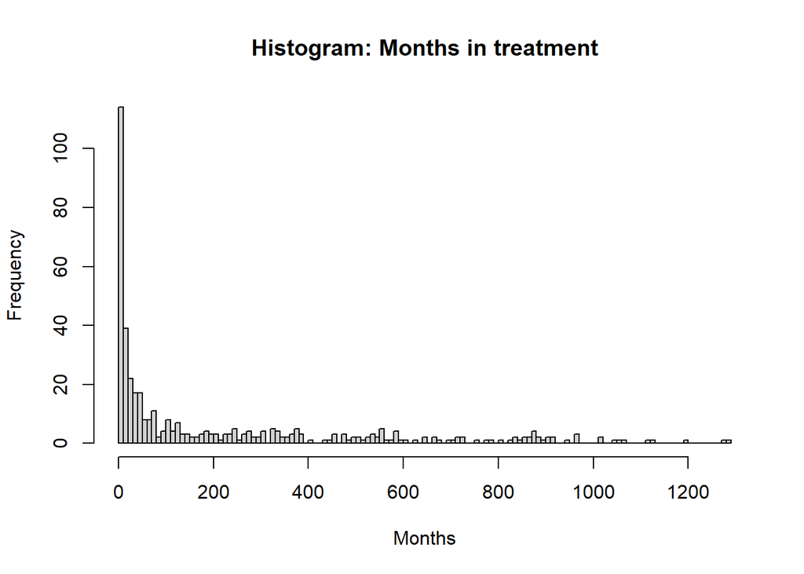

```
#:#:#:#:#:#:#:#:#:#:#:#:#:#:#:#:
Create dummied for psychiatric comorbidity
#:#:#:#:#:#:#:#:#:#:#:#:#:#:#:#:
Living arrangement/Cohabitation status
#:#:#:#:#:#:#:#:#:#:#:#:#:#:#:#:
Domestic violence & Sex abuse
#:#:#:#:#:#:#:#:#:#:#:#:#:#:#:#:
Primary subs
#:#:#:#:#:#:#:#:#:#:#:#:#:#:#:#:
Tr outcome
#:#:#:#:#:#:#:#:#:#:#:#:#:#:#:#:
#:#:#:#:#:#:#:#:#:#:#:#:#:#:#:#:
Recode Type of housing, Admission age, Treatment days, Tr. compliance; Nationallity (Chile);
#:#:#:#:#:#:#:#:#:#:#:#:#:#:#:#:
```

```r
#_#_#_#_#_#_#_#_#_#_#_#_#_#_#_#_#_#_#_#_#_#_#_#_#_#_#_#_#_#_#_#_#_#_#_#_#_#_#_#_#_#_#_#_#_#_#_#_#_#_#_#_
#_#_#_#_#_#_#_#_#_#_#_#_#_#_#_#_#_#_#_#_#_#_#_#_#_#_#_#_#_#_#_#_#_#_#_#_#_#_#_#_#_#_#_#_#_#_#_#_#_#_#_#_
cat("#:#:#:#:#:#:#:#:#:#:#:#:#:#:#:#:\n")
cat("Recode Type of housing, Admission age, Treatment days, Tr. compliance; Nationallity (Chile); \n")
cat("#:#:#:#:#:#:#:#:#:#:#:#:#:#:#:#:\n")

SISTRAT23_c1_2010_2024_df_prev1z <- within(SISTRAT23_c1_2010_2024_df_prev1z, {
  tipo_de_vivienda_rec <- factor(tidytable::case_when(
    tipo_de_vivienda %in% c("casa", "departamento") ~ "formal housing",
    tipo_de_vivienda == "pieza dentro de la vivienda" ~ "shared/secondary unit",
    tipo_de_vivienda%in% c("caleta o punto de calle", "mediagua movil (carpa, casa rodante o similar)", "hospederia", "residencial, pension, hostal", "choza, rancho, ruca", "informal/rural housing") ~ "homeless/unsheltered/informal/temporary housing/institutional/collective",
    is.na(tipo_de_vivienda)~ NA_character_,
    TRUE ~ "other/unknown"  # catches "otro" and NA
    ),
  levels = c(
    "formal housing",
    "shared/secondary unit",
    "homeless/unsheltered/informal/temporary housing/institutional/collective",
    "other/unknown"
    ))
})

SISTRAT23_c1_2010_2024_df_prev1z <- within(SISTRAT23_c1_2010_2024_df_prev1z, {
  prim_sub_freq_rec <- factor(tidytable::case_when(
    prim_sub_freq %in% c("1. Less than 1 day a week", "2. 1 day a week")~ "1.≤1 day/wk",
    prim_sub_freq %in% c("3. 2 to 3 days a week", "4. 4 to 6 days a week")~ "2.2–6 days/wk",
    is.na(prim_sub_freq)~ NA_character_,
    TRUE ~ "3.Daily"  # catches "otro" and NA
    ),
  levels = c(
    "1.≤1 day/wk",
    "2.2–6 days/wk",
    "3.Daily"
    ))
})

SISTRAT23_c1_2010_2024_df_prev1z <- within(SISTRAT23_c1_2010_2024_df_prev1z, {
  tipo_de_vivienda_rec2 <- factor(tidytable::case_when(
    tipo_de_vivienda %in% c("casa", "departamento") ~ "formal housing",
    # tipo_de_vivienda == "pieza dentro de la vivienda" ~ "shared/secondary unit",
    # tipo_de_vivienda%in% c("caleta o punto de calle", "mediagua movil (carpa, casa rodante o similar)", "hospederia", "residencial, pension, hostal", "choza, rancho, ruca", "informal/rural housing") ~ "homeless/unsheltered/informal/temporary housing/institutional/collective",
    is.na(tipo_de_vivienda)~ NA_character_,
    TRUE ~ "other/unknown"  # catches "otro" and NA
    ),
  levels = c(
    "formal housing",
    # "shared/secondary unit",
    # "homeless/unsheltered/informal/temporary housing/institutional/collective",
    "other/unknown"
    ))
})

#Admission age
SISTRAT23_c1_2010_2024_df_prev1z$adm_age_log <- with(SISTRAT23_c1_2010_2024_df_prev1z,
  ifelse(is.na(adm_age_rec3), NA_real_, log1p(adm_age_rec3)))

SISTRAT23_c1_2010_2024_df_prev1z$adm_age_c <- with(SISTRAT23_c1_2010_2024_df_prev1z,
  ifelse(is.na(adm_age_rec3), NA_real_, scale(adm_age_rec3, center = TRUE, scale = FALSE)))

#Warning in log1p(adm_age_rec3) : Se han producido NaNs
SISTRAT23_c1_2010_2024_df_prev1z$adm_age_pow2 <- with(SISTRAT23_c1_2010_2024_df_prev1z,
  ifelse(is.na(adm_age_rec3), NA_real_, adm_age_rec3^2))
SISTRAT23_c1_2010_2024_df_prev1z$adm_age_pow3 <- with(SISTRAT23_c1_2010_2024_df_prev1z,
  ifelse(is.na(adm_age_rec3), NA_real_, adm_age_rec3^3))

# Admission Age categories
SISTRAT23_c1_2010_2024_df_prev1z$adm_age_cat <- with(
    SISTRAT23_c1_2010_2024_df_prev1z,
    {
        res <- rep(NA_character_, length(adm_age_rec3))
        res[adm_age_rec3 >= 18 & adm_age_rec3 < 30] <- "18-29"
        res[adm_age_rec3 >= 30 & adm_age_rec3 < 45] <- "30-44"
        res[adm_age_rec3 >= 45 & adm_age_rec3 < 65] <- "45-64"
        res
    }
)
SISTRAT23_c1_2010_2024_df_prev1z$adm_age_cat <- factor(
  SISTRAT23_c1_2010_2024_df_prev1z$adm_age_cat,
  levels = c("18-29", "30-44", "45-64")
)
SISTRAT23_c1_2010_2024_df_prev1z$adm_age_c <- scale(SISTRAT23_c1_2010_2024_df_prev1z$adm_age_rec3, center = TRUE, scale = FALSE)


invisible("Created the 90 days translated in months by subsetting and taking the average value")
dit90<-
mean(SISTRAT23_c1_2010_2024_df_prev1z$dit_m[which(SISTRAT23_c1_2010_2024_df_prev1z$dit_rec6==90)])

# Treatment duration transformations
SISTRAT23_c1_2010_2024_df_prev1z$treat_log <- with(SISTRAT23_c1_2010_2024_df_prev1z,
  ifelse(is.na(dit_m), NA_real_, log1p(dit_m)))
#Warning in log1p(dit_m) : Se han producido NaNs
SISTRAT23_c1_2010_2024_df_prev1z$treat_days_pow2 <- with(SISTRAT23_c1_2010_2024_df_prev1z,
  ifelse(is.na(dit_m), NA_real_, dit_m^2))
SISTRAT23_c1_2010_2024_df_prev1z$treat_days_pow3 <- with(SISTRAT23_c1_2010_2024_df_prev1z,
  ifelse(is.na(dit_m), NA_real_, dit_m^3))
SISTRAT23_c1_2010_2024_df_prev1z$treat_lt_90 <- with(SISTRAT23_c1_2010_2024_df_prev1z,
  ifelse(is.na(dit_m), NA_integer_, as.integer(dit_m < dit90)))

SISTRAT23_c1_2010_2024_df_prev1z <- within(SISTRAT23_c1_2010_2024_df_prev1z, {
  sex_rec <- dplyr::case_when(
    sex_rec == "mujer" ~ "woman",
    sex_rec == "hombre" ~ "man",
    T~ NA_character_
  )
  sex_rec <- factor(sex_rec, levels = c(
    "man",
    "woman"
  ))
})
SISTRAT23_c1_2010_2024_df_prev1z <- within(SISTRAT23_c1_2010_2024_df_prev1z, {
  nationality_chile <- dplyr::case_when(
    nationality_cons== "chile" ~ "chile",
    !nationality_cons== "chile" ~ "other",
    T~ NA_character_
  )
  nationality_chile <- factor(nationality_chile, levels = c(
    "chile",
    "other"
  ))
})

SISTRAT23_c1_2010_2024_df_prev1z <- within(SISTRAT23_c1_2010_2024_df_prev1z, {
  any_violence <- dplyr::case_when(
    sex_abuse== "Sexual abuse"| dom_violence=="Domestic violence"~ "1.Domestic violence/sex abuse",
    grepl("No", sex_abuse) & grepl("No", dom_violence)~ "0.No domestic violence/sex abuse",
    grepl("No", sex_abuse) & is.na(dom_violence)~ "0.No domestic violence/sex abuse",
    is.na(sex_abuse) & grepl("No", dom_violence)~ "0.No domestic violence/sex abuse",
    T~ NA_character_
  )
  any_violence <- factor(any_violence, levels = c(
    "1.Domestic violence/sex abuse",
    "0.No domestic violence/sex abuse"
  ))
})
#:#:#:#:#:#:#:#:#:#:#:#:#:#:#:#:#:#:#:#:#:#:#:#:#:#:#:#:#:#:#:#:
#:#:#:#:#:#:#:#:#:#:#:#:#:#:#:#:#:#:#:#:#:#:#:#:#:#:#:#:#:#:#:#:

# 1) Define supergroup sets and a vectorized classifier that keeps NAs as NA
infectious_set <- c(
  "ets",
  "hepatitis b, c, d",
  "infecciosas relacionadas con uso de sustancias"
)
organ_set <- c(
  "cardiopatias: miocardiopatia dilatada por oh, arritmias, hta",
  "hepatitis alcoholica subaguda",
  "hepatitis cronica",
  "patologia bucal",
  "anemia: megaloblastica y ferropenica"
)
injury_set <- c("traumatismos y secuelas secundarios")
other_spec_set <- c(
  "otras enfermedades o condiciones fisicas limitantes",
  "otras enfermedades o condiciones de riesgo vital",
  "enfermedades somaticas",
  "patologia de la gestion y del nino intrauterino"
)
supergroups_levels <- c(
  "en estudio",
  "sin trastorno",
  "Infectious diseases (STIs, viral hepatitis, substance-use–related)",
  "Organ-system medical diseases (cardio, hepatic, oral, hematologic)",
  "Injuries and sequelae",
  "Other specified medical conditions"
)
classify_dx_vec <- function(x) {
  x <- stringr::str_squish(x)
  out <- rep(NA_character_, length(x))
  # statuses (kept as-is)
  out[x == "en estudio"] <- "en estudio"
  out[x == "sin trastorno"] <- "sin trastorno"
  # infectious
  out[x %in% infectious_set] <- "Infectious diseases (STIs, viral hepatitis, substance-use–related)"
  # organ/system
  out[x %in% organ_set] <- "Organ-system medical diseases (cardio, hepatic, oral, hematologic)"
  # injuries
  out[x %in% injury_set] <- "Injuries and sequelae"
  # other specified (broad/vague)
  out[x %in% other_spec_set] <- "Other specified medical conditions"
  # funnel any unforeseen non-NA labels to "Other specified"
  out[is.na(out) & !is.na(x)] <- "Other specified medical conditions"
  out
}
# 2) Apply to the single-diagnosis field; keep is.na(.) as NA
SISTRAT23_c1_2010_2024_df_prev1z <- SISTRAT23_c1_2010_2024_df_prev1z|>
  dplyr::mutate(
    phys_dx_supergroup = classify_dx_vec(diagnostico_trs_fisico),
    phys_dx_supergroup = forcats::fct_relevel(
      factor(phys_dx_supergroup),
      supergroups_levels))
# 3) Apply to the multi-response series (split on "||", classify, dedup per row)
#    - Produce: a collapsed string per row and wide one-hot indicators
multi_tokens <- SISTRAT23_c1_2010_2024_df_prev1z|>
  dplyr::mutate(.rowid = dplyr::row_number(),
                dx_series_raw = diagnostico_trs_fisico_series)|>
  tidyr::separate_rows(dx_series_raw, sep = "\\|\\|")|>
  dplyr::mutate(
    dx_token = stringr::str_squish(dx_series_raw),
    dx_token = dplyr::na_if(dx_token, ""),
    dx_token = dplyr::na_if(dx_token, "NA"),
    supergroup_token = classify_dx_vec(dx_token)
  )|>
  dplyr::distinct(.rowid, supergroup_token, .keep_all = TRUE)
# Collapsed string per row (NA if nothing classifiable present)
series_collapsed <- multi_tokens|>
  dplyr::filter(!is.na(supergroup_token))|>
  dplyr::group_by(.rowid)|>
  dplyr::summarise(
    dx_supergroup_series = paste(sort(unique(supergroup_token)), collapse = "||"),
    .groups = "drop"
  )
# One-hot indicators per supergroup (sanitized column names)
series_dummies <- multi_tokens|>
  dplyr::filter(!is.na(supergroup_token))|>
  dplyr::mutate(value = 1L)|>
  dplyr::distinct(.rowid, supergroup_token, .keep_all = TRUE)|>
  tidyr::pivot_wider(
    names_from = supergroup_token,
    values_from = value,
    values_fill = list(value = 0)
  )|>
  dplyr::rename_with(.fn = base::make.names, .cols = - .rowid)|>
  dplyr::select(dplyr::any_of(c(".rowid", "hash_key", "en.estudio", "Other.specified.medical.conditions", "Organ.system.medical.diseases..cardio..hepatic..oral..hematologic.", "sin.trastorno", "Injuries.and.sequelae", "Infectious.diseases..STIs..viral.hepatitis..substance.use.related.")))|>
  janitor::clean_names()|>
  dplyr::rename("phys_dg_org_med_card_hep_oral_hem"="organ_system_medical_diseases_cardio_hepatic_oral_hematologic", "phys_dg_infect_viral_hep_sud_rel"="infectious_diseases_st_is_viral_hepatitis_substance_use_related", "phys_dg_instudy"="en_estudio", "phys_dg_other_med_cond"="other_specified_medical_conditions", "phys_dg_inj_sequelae"="injuries_and_sequelae")|>
  dplyr::group_by(hash_key)|>
  dplyr::summarise(
    phys_dx_instudy = sum(phys_dg_instudy, na.rm = TRUE),
    phys_dx_other_spec_medical_cond = sum(phys_dg_other_med_cond, na.rm = TRUE),
    phys_dx_organ_system_med_dis = sum(phys_dg_org_med_card_hep_oral_hem, na.rm = TRUE),
    phys_dx_injuries_and_sequelae = sum(phys_dg_inj_sequelae, na.rm = TRUE),
    phys_dx_infectious_diseases = sum(phys_dg_infect_viral_hep_sud_rel, na.rm = TRUE),
    .groups = "drop"
  )|>
  # Optional: Reorder columns for clarity (hash_key first, then dummies)
  dplyr::select(hash_key, dplyr::everything())
# 4) Join back to your main data (keeps rows with NA series as NA)
SISTRAT23_c1_2010_2024_df_prev1z <- SISTRAT23_c1_2010_2024_df_prev1z|>
  dplyr::mutate(.rowid = dplyr::row_number())|>
  dplyr::left_join(series_collapsed, by = ".rowid", multiple="first")|>
  dplyr::left_join(series_dummies,  by = "hash_key", multiple="first")|>
  dplyr::select(-.rowid)|>
  dplyr::mutate(
    # assuming logical columns like dx_F0, dx_F2, ..., dx_F8_9
    dx_f2_smi_psychotic   = as.integer(f2_psychotic),
    dx_f3_mood            = as.integer(f3_mood),
    dx_f45_anx_stress_phys = as.integer(f4_anxiety_stress_somatoform| f5_physio_eating_sleep_sexual),
    dx_f6_personality     = as.integer(f6_personality_adult_behaviour),
    dx_f0789_neurocog_dev    = as.integer(f0_organic | f7_intellectual_disability | f8_9_neurodevelopment_child)
    # optional: single collapsed factor, with priority
  )

#:#:#:#:#:#:#:#:#:#:#:#:#:#:#:#:#:#:#:#:#:#:#:#:#:#:#:#:#:#:#:#:
hist(table(round(SISTRAT23_c1_2010_2024_df_prev1z$dit_m,1), exclude=NULL), breaks=120, main= "Histogram: Months in treatment", xlab="Months")
```

### 1.4. Missingness

We assessed missing data across predictors, calculating the overall proportion of complete cases and percentage of missing values for each variable.

```r
# Character vector of the variables
tot_variables <- c(
  "readmit_time_from_adm_m", "readmit_time_from_disch_m", "readmit_event",
  "death_time_from_adm_m", "death_time_from_disch_m", "death_event",
  "sex_rec", "adm_age_log", "adm_age_pow2", "adm_age_pow3", "adm_age_c", "adm_age_cat", "tenure_status_household", "occupation_condition_corr24",
  "marital_status_rec", "porc_pobr", "porc_pobr_log", "porc_pobr_c",
  "ethnicity", "nationality_chile", "urbanicity_cat", "ed_attainment_corr", "cohabitation",
  "dg_psiq_cie_10_instudy", "dg_psiq_cie_10_dg",  "f0_organic", "f1_substance_use", "f2_psychotic",
  "f3_mood", "f4_anxiety_stress_somatoform", "f5_physio_eating_sleep_sexual",
  "f6_personality_adult_behaviour", "f7_intellectual_disability", "f8_9_neurodevelopment_child",
  "dx_f2_smi_psychotic", "dx_f3_mood", "dx_f45_anx_stress_phys", "dx_f6_personality", "dx_f0789_neurocog_dev",
  "sub_dep_icd10_status", "dom_violence", "sex_abuse", "any_violence",
  "phys_dx_supergroup","phys_dx_instudy", "phys_dx_other_spec_medical_cond", "phys_dx_organ_system_med_dis",
  "phys_dx_injuries_and_sequelae", "phys_dx_infectious_diseases",
  "prim_sub_freq", "prim_sub_freq_rec", "polysubstance_strict", "dit_m", "treat_log",
  "treat_days_pow2", "treat_days_pow3", "treat_lt_90", "tr_outcome",
  "adm_motive", "primary_sub", "primary_sub_mod", "usuario_tribunal_trat_droga",
  "tipo_de_vivienda_rec", "tipo_de_vivienda_rec2", "plan_type_corr", "evaluacindelprocesoteraputico",

  "eva_consumo", "eva_fam", "eva_relinterp", "eva_ocupacion", "eva_sm", "eva_fisica", "eva_transgnorma"
)
# Character vector of the variables restricted to factor or character columns
char_variables <- c(
  "sex_rec", "tenure_status_household", "occupation_condition_corr24",
  "marital_status_rec", "ethnicity", "urbanicity_cat", "ed_attainment_corr", "cohabitation",
  "dg_psiq_cie_10_instudy", "dg_psiq_cie_10_dg", "f0_organic", "f1_substance_use", "f2_psychotic",
  "f3_mood", "f4_anxiety_stress_somatoform", "f5_physio_eating_sleep_sexual",
  "f6_personality_adult_behaviour", "f7_intellectual_disability", "f8_9_neurodevelopment_child",
  "dx_f2_smi_psychotic", "dx_f3_mood", "dx_f45_anx_stress_phys", "dx_f6_personality", "dx_f0789_neurocog_dev",
  "sub_dep_icd10_status", "dom_violence", "sex_abuse", "any_violence",
  "phys_dx_supergroup", "phys_dx_instudy", "phys_dx_other_spec_medical_cond", "phys_dx_organ_system_med_dis",
  "phys_dx_injuries_and_sequelae", "phys_dx_infectious_diseases",
  "prim_sub_freq", "prim_sub_freq_rec", "polysubstance_strict", "treat_lt_90", "tr_outcome",
  "adm_motive", "primary_sub", "primary_sub_mod", "usuario_tribunal_trat_droga",
  "tipo_de_vivienda_rec", "tipo_de_vivienda_rec2", "plan_type_corr", "evaluacindelprocesoteraputico",
  "eva_consumo", "eva_fam", "eva_relinterp", "eva_ocupacion", "eva_sm", "eva_fisica", "eva_transgnorma"
)

paste0( "Percentage of the total that has missing values: ",
  scales::percent(1- (
      SISTRAT23_c1_2010_2024_df_prev1z[
        which(complete.cases(subset(SISTRAT23_c1_2010_2024_df_prev1z, select = tot_variables
            ))),] %>% nrow() / nrow(SISTRAT23_c1_2010_2024_df_prev1z)
    ), accuracy = 0.1),
  "; total = ", format(nrow(SISTRAT23_c1_2010_2024_df_prev1z), big.mark = ",")
)
paste0( "Percentage of the total that has missing values (w/o other variables): ",
  scales::percent(1- (
      SISTRAT23_c1_2010_2024_df_prev1z[
        which(complete.cases(subset(SISTRAT23_c1_2010_2024_df_prev1z, select = setdiff(tot_variables,   c("usuario_tribunal_trat_droga", "dom_violence", "sex_abuse", "any_violence", "ethnicity", "tipo_de_vivienda_rec", "tipo_de_vivienda_rec2", "phys_dx_supergroup", "phys_dx_instudy", "phys_dx_other_spec_medical_cond", "phys_dx_organ_system_med_dis", "phys_dx_injuries_and_sequelae", "evaluacindelprocesoteraputico"))
            ))),] %>% nrow() / nrow(SISTRAT23_c1_2010_2024_df_prev1z)
    ), accuracy = 0.1),
  "; total = ", format(nrow(SISTRAT23_c1_2010_2024_df_prev1z), big.mark = ",")
)

# Variables to check
vars_check <- c(tot_variables)
# Compute % missing per variable
missing_pct <- colMeans(
  is.na(subset(SISTRAT23_c1_2010_2024_df_prev1z, select = vars_check))
) * 100
#:#:#:#:#:#:#:#:#:#:#:#:#:#:#:#:#:#:#:#:#:#:#:#:#:#:#:#:#:#:#:#:#:#:#:#:#:#:#:#:
#:#:#:#:#:#:#:#:#:#:#:#:#:#:#:#:#:#:#:#:#:#:#:#:#:#:#:#:#:#:#:#:#:#:#:#:#:#:#:#:
# Named vector of labels (names = variable names)
labels_map <- c(
  # Times & events
  readmit_time_from_adm_m         = "Readmission time from admission (months)",
  readmit_time_from_disch_m       = "Readmission time from discharge (months)",
  death_time_from_adm_m           = "Death time from admission (months)",
  death_time_from_disch_m         = "Death time from discharge (months)",
  readmit_event                   = "Readmission event",
  death_event                     = "Death event",

  # Demographics & status
  sex_rec                         = "Sex (biological categorization)",
  tenure_status_household         = "Housing situation",
  tenure_status_household_rec     = "Housing situation (- informal settlement)",
  occupation_condition_corr24     = "Employment status",
  marital_status_rec              = "Marital status",
  ed_attainment_corr              = "Educational attainment",
  ethnicity                       = "Ethnicity (=1)",
  nationality_chile               = "Nationality (Chile)",
  adm_age_log                     = "Admission age (log)",
  adm_age_pow2                    = "Admission age ^2",
  adm_age_pow3                    = "Admission age ^3",
  adm_age_c                       = "Admission age (centered)",
  adm_age_cat                     = "Admission age (three groups)",

  # Contextual
  porc_pobr                       = "Poverty index of commune of residence",
  porc_pobr_log                   = "Poverty index (log1p)",
  porc_pobr_c                     = "Poverty index (centered)",
  porc_pobr_c_cat6                = "Poverty index (6 quantile groups)",
  urbanicity_cat                  = "Urbanization level of commune of residence",

  # Living arrangement
  cohabitation                    = "Cohabitation status (harmonized)",

  # Clinical/behavioral
  dg_psiq_cie_10_instudy          = "Psychiatric comorbidity (ICD-10, in-study)",
  dg_psiq_cie_10_dg               = "Psychiatric comorbidity (ICD-10, diagnosis record)",
  sub_dep_icd10_status            = "SUD severity (ICD-10)",
  prim_sub_freq                   = "Primary-substance use frequency at admission",
  prim_sub_freq_rec               = "Primary-substance use frequency at admission (simplified)",
  polysubstance_strict            = "Polysubstance use (strict)",

  # Treatment exposure
  dit_m                           = "Length of stay in treatment (months)",
  treat_log                       = "Length of stay (log1p months)",
  treat_days_pow2                 = "Length of stay (months)^2",
  treat_days_pow3                 = "Length of stay (months)^3",
  treat_lt_90                     = "Treatment length < 90 days (indicator)",
  tr_outcome                      = "Treatment outcome",
  adm_motive                      = "Admission motive",
  primary_sub                     = "Primary substance of use (detailed substances)",
  primary_sub_mod                 = "Primary substance of use (recoded)",

  # Research-context extras
  usuario_tribunal_trat_droga     = "Court-referred to drug treatment (1 = yes)",
  tipo_de_vivienda_rec            = "Housing type (recoded)",
  tipo_de_vivienda_rec2           = "Housing type (recoded & simplified)",

  # Stratification
  plan_type_corr                  = "Treatment modality (plan type)",
  prim_sub_licit                  = "Licit primary substance at admission",
  f0_organic                      = "F0. Organic, including symptomatic, mental disorders",
  f1_substance_use                = "F1. Mental and behavioural disorders due to psychoactive substance use",
  f2_psychotic                    = "F2. Schizophrenia, schizotypal and delusional disorders",
  f3_mood                         = "F3. Mood [affective] disorders",
  f4_anxiety_stress_somatoform    = "F4. Neurotic, stress-related and somatoform disorders",
  f5_physio_eating_sleep_sexual   = "F5. Behavioural syndromes associated with physiological disturbances and physical factors",
  f6_personality_adult_behaviour  = "F6. Disorders of adult personality and behaviour",
  f7_intellectual_disability      = "F7. Intellectual disability",
  f8_9_neurodevelopment_child     = "F8-9. Disorders of psychological development and behavioural/emotional disorders with onset in childhood and adolescence",
  dx_f2_smi_psychotic             = "Psychotic disorders (F2)",
  dx_f3_mood                      = "Mood disorders (F3)",
  dx_f45_anx_stress_phys          = "Anxiety & stress-related (F4–F5)",
  dx_f6_personality               = "Personality disorders (F6)",
  dx_f0789_neurocog_dev           = "Neurocognitive & neurodevelopmental (F0, F7–F9)",

  # Violence indicators
  any_violence                    = "Domestic violence/Sexual abuse",
  dom_violence                    = "Domestic violence",
  sex_abuse                       = "Sexual abuse",

  # Physical diagnosis groups
  phys_dx_supergroup              = "Physical diagnosis supergroup (single)",
  phys_dx_instudy                 = "Physical diagnosis: under study",
  phys_dx_other_spec_medical_cond = "Physical diagnosis: other medical conditions",
  phys_dx_organ_system_med_dis    = "Physical diagnosis: organ-system diseases",
  phys_dx_injuries_and_sequelae   = "Physical diagnosis: injuries & sequelae",
  phys_dx_infectious_diseases     = "Physical diagnosis: infectious diseases",

  # Evaluation at discharge
  evaluacindelprocesoteraputico   = "Assessment of the therapeutic process",
  eva_consumo                     = "Evaluation of consumption pattern at discharge",
  eva_fam                         = "Family situation evaluation at discharge",
  eva_relinterp                   = "Interpersonal relations evaluation at discharge",
  eva_ocupacion                   = "Occupational situation evaluation at discharge",
  eva_sm                          = "Mental health evaluation at discharge",
  eva_fisica                      = "Physical health evaluation at discharge",
  eva_transgnorma                 = "Social norm transgression evaluation at discharge"
)

# Apply labels safely (only to variables that exist)
for(nm in intersect(names(SISTRAT23_c1_2010_2024_df_prev1z), names(labels_map))){
  attr(SISTRAT23_c1_2010_2024_df_prev1z[[nm]],"label")<-labels_map[[nm]]
}
# Extract labels for each variable, defaulting to NA if not present
labels_vec <- sapply(names(missing_pct), function(nm) {
  lbl <- attr(SISTRAT23_c1_2010_2024_df_prev1z[[nm]], "label")
  if (is.null(lbl)) NA_character_ else lbl
})

# Round and format into data.frame with labels
data.frame(
  Variable = names(missing_pct),
  Label = labels_vec,
  Missing_Percent = round(missing_pct, 2))|>
  # Display as markdown table
  knitr::kable(format = "markdown",
    align = c("l", "l", "r"),
    col.names = c("Variable", "Label", "% Missing"),
    row.names = FALSE)
```

```
[1] "Percentage of the total that has missing values: 33.3%; total = 88,504"
[1] "Percentage of the total that has missing values (w/o other variables): 6.3%; total = 88,504"
```

| Variable | Label | % Missing |
| --- | --- | --- |
| readmit_time_from_adm_m | Readmission time from admission (months) | 0.00 |
| readmit_time_from_disch_m | Readmission time from discharge (months) | 0.00 |
| readmit_event | Readmission event | 0.00 |
| death_time_from_adm_m | Death time from admission (months) | 0.00 |
| death_time_from_disch_m | Death time from discharge (months) | 0.00 |
| death_event | Death event | 0.00 |
| sex_rec | Sex (biological categorization) | 0.00 |
| adm_age_log | Admission age (log) | 0.00 |
| adm_age_pow2 | Admission age ^2 | 0.00 |
| adm_age_pow3 | Admission age ^3 | 0.00 |
| adm_age_c | Admission age (centered) | 0.00 |
| adm_age_cat | Admission age (three groups) | 0.00 |
| tenure_status_household | Housing situation | 5.06 |
| occupation_condition_corr24 | Employment status | 0.00 |
| marital_status_rec | Marital status | 0.18 |
| porc_pobr | Poverty index of commune of residence | 0.00 |
| porc_pobr_log | Poverty index (log1p) | 0.00 |
| porc_pobr_c | Poverty index (centered) | 0.00 |
| ethnicity | Ethnicity (=1) | 0.00 |
| nationality_chile | Nationality (Chile) | 0.00 |
| urbanicity_cat | Urbanization level of commune of residence | 0.00 |
| ed_attainment_corr | Educational attainment | 0.43 |
| cohabitation | Cohabitation status (harmonized) | 0.00 |
| dg_psiq_cie_10_instudy | Psychiatric comorbidity (ICD-10, in-study) | 0.00 |
| dg_psiq_cie_10_dg | Psychiatric comorbidity (ICD-10, diagnosis record) | 0.00 |
| f0_organic | F0. Organic, including symptomatic, mental disorders | 0.00 |
| f1_substance_use | F1. Mental and behavioural disorders due to psychoactive substance use | 0.00 |
| f2_psychotic | F2. Schizophrenia, schizotypal and delusional disorders | 0.00 |
| f3_mood | F3. Mood [affective] disorders | 0.00 |
| f4_anxiety_stress_somatoform | F4. Neurotic, stress-related and somatoform disorders | 0.00 |
| f5_physio_eating_sleep_sexual | F5. Behavioural syndromes associated with physiological disturbances and physical factors | 0.00 |
| f6_personality_adult_behaviour | F6. Disorders of adult personality and behaviour | 0.00 |
| f7_intellectual_disability | F7. Intellectual disability | 0.00 |
| f8_9_neurodevelopment_child | F8-9. Disorders of psychological development and behavioural/emotional disorders with onset in childhood and adolescence | 0.00 |
| dx_f2_smi_psychotic | Psychotic disorders (F2) | 0.00 |
| dx_f3_mood | Mood disorders (F3) | 0.00 |
| dx_f45_anx_stress_phys | Anxiety & stress-related (F4–F5) | 0.00 |
| dx_f6_personality | Personality disorders (F6) | 0.00 |
| dx_f0789_neurocog_dev | Neurocognitive & neurodevelopmental (F0, F7–F9) | 0.00 |
| sub_dep_icd10_status | SUD severity (ICD-10) | 0.00 |
| dom_violence | Domestic violence | 20.09 |
| sex_abuse | Sexual abuse | 20.09 |
| any_violence | Domestic violence/Sexual abuse | 20.09 |
| phys_dx_supergroup | Physical diagnosis supergroup (single) | 0.17 |
| phys_dx_instudy | Physical diagnosis: under study | 0.17 |
| phys_dx_other_spec_medical_cond | Physical diagnosis: other medical conditions | 0.17 |
| phys_dx_organ_system_med_dis | Physical diagnosis: organ-system diseases | 0.17 |
| phys_dx_injuries_and_sequelae | Physical diagnosis: injuries & sequelae | 0.17 |
| phys_dx_infectious_diseases | Physical diagnosis: infectious diseases | 0.17 |
| prim_sub_freq | Primary-substance use frequency at admission | 0.46 |
| prim_sub_freq_rec | Primary-substance use frequency at admission (simplified) | 0.46 |
| polysubstance_strict | Polysubstance use (strict) | 0.00 |
| dit_m | Length of stay in treatment (months) | 0.00 |
| treat_log | Length of stay (log1p months) | 0.00 |
| treat_days_pow2 | Length of stay (months)^2 | 0.00 |
| treat_days_pow3 | Length of stay (months)^3 | 0.00 |
| treat_lt_90 | Treatment length < 90 days (indicator) | 0.00 |
| tr_outcome | Treatment outcome | 0.00 |
| adm_motive | Admission motive | 0.00 |
| primary_sub | Primary substance of use (detailed substances) | 0.00 |
| primary_sub_mod | Primary substance of use (recoded) | 0.00 |
| usuario_tribunal_trat_droga | Court-referred to drug treatment (1 = yes) | 4.40 |
| tipo_de_vivienda_rec | Housing type (recoded) | 7.26 |
| tipo_de_vivienda_rec2 | Housing type (recoded & simplified) | 7.26 |
| plan_type_corr | Treatment modality (plan type) | 0.00 |
| evaluacindelprocesoteraputico | Assessment of the therapeutic process | 0.25 |
| eva_consumo | Evaluation of consumption pattern at discharge | 0.27 |
| eva_fam | Family situation evaluation at discharge | 0.27 |
| eva_relinterp | Interpersonal relations evaluation at discharge | 0.27 |
| eva_ocupacion | Occupational situation evaluation at discharge | 0.27 |
| eva_sm | Mental health evaluation at discharge | 0.27 |
| eva_fisica | Physical health evaluation at discharge | 0.27 |
| eva_transgnorma | Social norm transgression evaluation at discharge | 0.27 |

#### 1.4.* Currently in

We identified 215 cases with missing treatment outcomes. For these cases, treatment outcome, duration of treatment, and other treatment-related variables (e.g., evaluation at discharge) are unknown.

```r
SISTRAT23_c1_2010_2024_df_prev1z|>
  dplyr::filter(tr_outcome=="other")|>
  dplyr::select(hash_key, tr_outcome, adm_date_rec2, disch_date_rec6, dit_rec6, adm_year)|>
    #janitor::tabyl(adm_year)
  dplyr::mutate(
     hash_key = gsub(
         "(?<=^.{8}).{2}",   # lookbehind for first 8 chars, match the next 2
         "**",               # replace with two asterisks
         hash_key,
         perl = TRUE
     )) |>
  head()
```

```
# A tidytable: 6 × 6
  hash_key            tr_outcome adm_date_rec2 disch_date_rec6 dit_rec6 adm_year
  <chr>               <chr>      <date>        <date>             <dbl>    <int>
1 0065a4d6**af0c519d… other      2016-08-08    2019-08-09          1096     2016
2 00be34d5**32b9d1ee… other      2016-04-13    2019-04-14          1096     2016
3 01fea888**92b29fcc… other      2019-05-01    2022-05-01          1096     2019
4 0426e03d**26cb489d… other      2011-04-27    2014-04-27          1096     2011
5 048e829d**f1109af2… other      2011-07-25    2014-07-25          1096     2011
6 04b987f5**a824ea89… other      2011-02-07    2014-02-07          1096     2011
```

### 1.5. Descriptives

```r
## 0) Guard: use only columns that exist
tot_variables_present<-intersect(tot_variables,names(SISTRAT23_c1_2010_2024_df_prev1z))
char_variables_present<-intersect(c(char_variables, "readmit_event", "death_event"),names(SISTRAT23_c1_2010_2024_df_prev1z))
extra_cat<-intersect(c("disch_age_cat"),names(SISTRAT23_c1_2010_2024_df_prev1z))
extra_num<-intersect(c("disch_age_rec"),names(SISTRAT23_c1_2010_2024_df_prev1z))

categorical_vars<-union(char_variables_present,extra_cat)
numerical_vars<-setdiff(union(tot_variables_present,union(extra_cat,extra_num)),categorical_vars)

## 1) Create TableOne (coerce character categoricals to factor inline)
table_one_clean<-tableone::CreateTableOne(
  vars= setdiff(c(categorical_vars,numerical_vars), "plan_type_corr"),
  data= tidytable::mutate(SISTRAT23_c1_2010_2024_df_prev1z,
    tidytable::across(tidyselect::all_of(categorical_vars),\(x){if(is.character(x)) factor(x) else x}),
porc_pobr= porc_pobr*100),
  factorVars= setdiff(char_variables_present,"plan_type_corr"),
  strata= "plan_type_corr",
  addOverall= TRUE,
  test= TRUE,
  smd= TRUE#,
  #labelTranslations=label_map
)

## 4) Print (treat numeric as non-normal; keep your formatting)
escape_regex<-function(x) gsub("([][{}()+*^$.|?\\\\])","\\\\\\1",x)

rn<-rownames(table_one_clean_print)
keys<-names(labels_map)
keys<-keys[order(nchar(keys),decreasing=TRUE)]  # avoid partial overlaps

for(nm in keys){
  pat<-paste0("^",escape_regex(nm),"(?=\\s|\\(|:|=|$)")  # start, then space/(...)/: /= or end
  rn<-sub(pat,labels_map[[nm]],rn,perl=TRUE)            # replace only the prefix; keep the rest
}
rownames(table_one_clean_print)<-rn

wdpath<- paste0(gsub("/cons","",gsub("cons","",paste0(getwd(),"/cons"))))

## 5) HTML table
table_one_clean_print|>
  knitr::kable("html", caption= "Table 1. Descriptives by baseline treatment setting")|>
  kableExtra::kable_classic()|>
  kableExtra::row_spec(0:1, bold = TRUE)|>
  kableExtra::scroll_box(height = "400px")

write.table(table_one_clean_print,
            file= paste0(wdpath,"cons/_out/table_one_prediction_clean.txt"),
            sep = "\t", row.names = T)
```

Table 1. Descriptives by baseline treatment setting

|  | level | Overall | m-pai | m-pr | pg-pab | pg-pai | pg-pr | p | test | SMD | Missing |
| --- | --- | --- | --- | --- | --- | --- | --- | --- | --- | --- | --- |
| n |  | 88,504 | 5,263 | 3,545 | 32,424 | 37,555 | 9,717 |  |  |  |  |
| Sex (biological categorization) (%) | man | 65806 (74.4) | 0 (0.0) | 0 (0.0) | 26249 (81.0) | 30414 (81.0) | 9143 (94.1) | <0.001 |  | 2.377 | 0.0 |
|  | woman | 22696 (25.6) | 5263 (100.0) | 3545 (100.0) | 6175 (19.0) | 7139 (19.0) | 574 (5.9) |  |  |  |  |
| Housing situation (%) | illegal settlement | 947 (1.1) | 65 (1.3) | 86 (2.6) | 227 (0.7) | 340 (0.9) | 229 (2.7) | <0.001 |  | 0.200 | 5.1 |
|  | others | 2380 (2.8) | 139 (2.7) | 89 (2.7) | 974 (3.1) | 875 (2.4) | 303 (3.5) |  |  |  |  |
|  | owner/transferred dwellings/pays dividends | 30670 (36.5) | 1716 (33.4) | 940 (28.5) | 12047 (38.8) | 12451 (34.7) | 3516 (40.7) |  |  |  |  |
|  | renting | 15476 (18.4) | 1007 (19.6) | 471 (14.3) | 5936 (19.1) | 6818 (19.0) | 1244 (14.4) |  |  |  |  |
|  | stays temporarily with a relative | 34553 (41.1) | 2214 (43.1) | 1708 (51.9) | 11877 (38.2) | 15410 (42.9) | 3344 (38.7) |  |  |  |  |
| Employment status (%) | employed | 43336 (49.0) | 1603 (30.5) | 361 (10.2) | 21086 (65.0) | 18574 (49.5) | 1712 (17.6) | <0.001 |  | 0.792 | 0.0 |
|  | inactive | 14307 (16.2) | 1972 (37.5) | 1665 (47.0) | 3570 (11.0) | 5386 (14.3) | 1714 (17.6) |  |  |  |  |
|  | unemployed | 30861 (34.9) | 1688 (32.1) | 1519 (42.8) | 7768 (24.0) | 13595 (36.2) | 6291 (64.7) |  |  |  |  |
| Marital status (%) | married/cohabiting | 29768 (33.7) | 1662 (31.6) | 822 (23.2) | 13127 (40.6) | 11976 (31.9) | 2181 (22.5) | <0.001 |  | 0.211 | 0.2 |
|  | separated/divorced/annulled/widowed | 10269 (11.6) | 644 (12.2) | 441 (12.5) | 3881 (12.0) | 4234 (11.3) | 1069 (11.0) |  |  |  |  |
|  | single | 48304 (54.7) | 2953 (56.2) | 2277 (64.3) | 15339 (47.4) | 21279 (56.8) | 6456 (66.5) |  |  |  |  |
| Ethnicity (=1) (%) | 0 | 82870 (93.6) | 4868 (92.5) | 3312 (93.4) | 30386 (93.7) | 35158 (93.6) | 9146 (94.1) | 0.003 |  | 0.028 | 0.0 |
|  | 1 | 5634 (6.4) | 395 (7.5) | 233 (6.6) | 2038 (6.3) | 2397 (6.4) | 571 (5.9) |  |  |  |  |
| Urbanization level of commune of residence (%) | 1.Rural | 7669 (8.7) | 210 (4.0) | 187 (5.3) | 3030 (9.3) | 3803 (10.1) | 439 (4.5) | <0.001 |  | 0.176 | 0.0 |
|  | 2.Mixed | 8659 (9.8) | 383 (7.3) | 261 (7.4) | 4116 (12.7) | 3203 (8.5) | 696 (7.2) |  |  |  |  |
|  | 3.Urban | 72176 (81.6) | 4670 (88.7) | 3097 (87.4) | 25278 (78.0) | 30549 (81.3) | 8582 (88.3) |  |  |  |  |
| Educational attainment (%) | 1-More than high school | 16157 (18.3) | 899 (17.1) | 641 (18.1) | 5356 (16.6) | 7672 (20.5) | 1589 (16.4) | <0.001 |  | 0.085 | 0.4 |
|  | 2-Completed high school or less | 48791 (55.4) | 2785 (53.0) | 1855 (52.4) | 17756 (55.1) | 20891 (55.8) | 5504 (56.7) |  |  |  |  |
|  | 3-Completed primary school or less | 23176 (26.3) | 1567 (29.8) | 1042 (29.5) | 9108 (28.3) | 8847 (23.6) | 2612 (26.9) |  |  |  |  |
| Cohabitation status (harmonized) (%) | alone | 8415 (9.5) | 278 (5.3) | 337 (9.5) | 2815 (8.7) | 3404 (9.1) | 1581 (16.3) | <0.001 |  | 0.468 | 0.0 |
|  | with couple/children | 39730 (44.9) | 3507 (66.6) | 1828 (51.6) | 16525 (51.0) | 15679 (41.7) | 2191 (22.5) |  |  |  |  |
|  | family of origin | 32725 (37.0) | 1010 (19.2) | 954 (26.9) | 10683 (32.9) | 15142 (40.3) | 4936 (50.8) |  |  |  |  |
|  | Others | 7634 (8.6) | 468 (8.9) | 426 (12.0) | 2401 (7.4) | 3330 (8.9) | 1009 (10.4) |  |  |  |  |
| Psychiatric comorbidity (ICD-10, in-study) (%) | FALSE | 73020 (82.5) | 4482 (85.2) | 2678 (75.5) | 27173 (83.8) | 30921 (82.3) | 7766 (79.9) | <0.001 |  | 0.118 | 0.0 |
|  | TRUE | 15484 (17.5) | 781 (14.8) | 867 (24.5) | 5251 (16.2) | 6634 (17.7) | 1951 (20.1) |  |  |  |  |
| Psychiatric comorbidity (ICD-10, diagnosis record) (%) | FALSE | 49013 (55.4) | 2459 (46.7) | 1260 (35.5) | 20654 (63.7) | 19896 (53.0) | 4744 (48.8) | <0.001 |  | 0.256 | 0.0 |
|  | TRUE | 39491 (44.6) | 2804 (53.3) | 2285 (64.5) | 11770 (36.3) | 17659 (47.0) | 4973 (51.2) |  |  |  |  |

[output cut: 146 more lines]

```r
SISTRAT23_c1_2010_2024_df_prev1z|>
    janitor::tabyl(readmit_event, death_event)|>
    janitor::adorn_percentages("all")|>
    janitor::adorn_pct_formatting(digits = 1)|>
    janitor::adorn_ns(position = "front")|>
    knitr::kable("markdown", caption= "Intersection of Readmission (rows) w/ Mortality (cols)")
```

Intersection of Readmission (rows) w/ Mortality (cols)

| readmit_event | 0 | 1 |
| --- | --- | --- |
| 0 | 66,231 (74.8%) | 3,203 (3.6%) |
| 1 | 18,326 (20.7%) | 744 (0.8%) |